# wrangle_act

```python
import pandas as pd
import numpy as np
import requests
import tweepy
import re
import os
import json
import time
import warnings
import matplotlib.pyplot as plt
```

**Gathering data**

```python
# reading csv as a Pandas DataFrame
twitter_archive_enhanced = pd.read_csv('twitter-archive-enhanced.csv')
```

```python
# Downloading and saving data using Requests
url = 'https://d17h27t6h515a5.cloudfront.net/topher/2017/August/599fd2ad_image-predictions/image-predictions.tsv'
response = requests.get(url)

with open('image-predictions.tsv', mode ='wb') as file:
    file.write(response.content)

#Reading TSV file
image_prediction = pd.read_csv('image-predictions.tsv', sep='\t' )
```

```python
''''# Query Twitter API for each tweet in the Twitter archive and save JSON in a text file
# These are hidden to comply with Twitter's API terms and conditions
consumer_key = 'HIDDEN'
consumer_secret = 'HIDDEN'
access_token = 'HIDDEN'
access_secret = 'HIDDEN'

auth = OAuthHandler(consumer_key, consumer_secret)
auth.set_access_token(access_token, access_secret)

api = tweepy.API(auth, wait_on_rate_limit=True)'''
```

```python
''''# NOTE TO STUDENT WITH MOBILE VERIFICATION ISSUES:
# df_1 is a DataFrame with the twitter_archive_enhanced.csv file. You may have to
# change line 17 to match the name of your DataFrame with twitter_archive_enhanced.csv
# NOTE TO REVIEWER: this student had mobile verification issues so the following
# Twitter API code was sent to this student from a Udacity instructor
# Tweet IDs for which to gather additional data via Twitter's API
tweet_ids = df_1.tweet_id.values
len(tweet_ids)'''
```

```python
''''# Query Twitter's API for JSON data for each tweet ID in the Twitter archive
count = 0
fails_dict = {}
start = timer()
# Save each tweet's returned JSON as a new line in a .txt file
with open('tweet_json.txt', 'w') as outfile:
    # This loop will likely take 20-30 minutes to run because of Twitter's rate limit
    for tweet_id in tweet_ids:
        count += 1
        print(str(count) + ": " + str(tweet_id))
        try:
            tweet = api.get_status(tweet_id, tweet_mode='extended')
            print("Success")
            json.dump(tweet._json, outfile)
            outfile.write('\n')
        except tweepy.TweepError as e:
            print("Fail")
            fails_dict[tweet_id] = e
            pass
end = timer()
print(end - start)
print(fails_dict)'''
```

```python
# Read text file line by line to create dataframe
tweets_data = []
with open('tweet_json.txt') as file:
    for line in file:
        try:
            tweet = json.loads(line)
            tweets_data.append(tweet)
        except:
            continue
df_api = pd.DataFrame(tweets_data, columns=list(tweets_data[0].keys()))
```

```python
df_json = df_api[['id', 'retweet_count', 'favorite_count']]
```

**ِAssess data**

```python
twitter_archive_enhanced
```

|  | tweet_id | in_reply_to_status_id | in_reply_to_user_id | timestamp | source | text | retweeted_status_id | retweeted_status_user_id | retweeted_status_timestamp | expanded_urls | rating_numerator | rating_denominator | name | doggo | floofer | pupper | puppo |
| --- | --- | --- | --- | --- | --- | --- | --- | --- | --- | --- | --- | --- | --- | --- | --- | --- | --- |
| 0 | 892420643555336193 | NaN | NaN | 2017-08-01 16:23:56 +0000 | <a href="http://twitter.com/download/iphone" r... | This is Phineas. He's a mystical boy. Only eve... | NaN | NaN | NaN | https://twitter.com/dog_rates/status/892420643... | 13 | 10 | Phineas | None | None | None | None |
| 1 | 892177421306343426 | NaN | NaN | 2017-08-01 00:17:27 +0000 | <a href="http://twitter.com/download/iphone" r... | This is Tilly. She's just checking pup on you.... | NaN | NaN | NaN | https://twitter.com/dog_rates/status/892177421... | 13 | 10 | Tilly | None | None | None | None |
| 2 | 891815181378084864 | NaN | NaN | 2017-07-31 00:18:03 +0000 | <a href="http://twitter.com/download/iphone" r... | This is Archie. He is a rare Norwegian Pouncin... | NaN | NaN | NaN | https://twitter.com/dog_rates/status/891815181... | 12 | 10 | Archie | None | None | None | None |
| 3 | 891689557279858688 | NaN | NaN | 2017-07-30 15:58:51 +0000 | <a href="http://twitter.com/download/iphone" r... | This is Darla. She commenced a snooze mid meal... | NaN | NaN | NaN | https://twitter.com/dog_rates/status/891689557... | 13 | 10 | Darla | None | None | None | None |
| 4 | 891327558926688256 | NaN | NaN | 2017-07-29 16:00:24 +0000 | <a href="http://twitter.com/download/iphone" r... | This is Franklin. He would like you to stop ca... | NaN | NaN | NaN | https://twitter.com/dog_rates/status/891327558... | 12 | 10 | Franklin | None | None | None | None |
| 5 | 891087950875897856 | NaN | NaN | 2017-07-29 00:08:17 +0000 | <a href="http://twitter.com/download/iphone" r... | Here we have a majestic great white breaching ... | NaN | NaN | NaN | https://twitter.com/dog_rates/status/891087950... | 13 | 10 | None | None | None | None | None |
| 6 | 890971913173991426 | NaN | NaN | 2017-07-28 16:27:12 +0000 | <a href="http://twitter.com/download/iphone" r... | Meet Jax. He enjoys ice cream so much he gets ... | NaN | NaN | NaN | https://gofundme.com/ydvmve-surgery-for-jax,ht... | 13 | 10 | Jax | None | None | None | None |
| 7 | 890729181411237888 | NaN | NaN | 2017-07-28 00:22:40 +0000 | <a href="http://twitter.com/download/iphone" r... | When you watch your owner call another dog a g... | NaN | NaN | NaN | https://twitter.com/dog_rates/status/890729181... | 13 | 10 | None | None | None | None | None |
| 8 | 890609185150312448 | NaN | NaN | 2017-07-27 16:25:51 +0000 | <a href="http://twitter.com/download/iphone" r... | This is Zoey. She doesn't want to be one of th... | NaN | NaN | NaN | https://twitter.com/dog_rates/status/890609185... | 13 | 10 | Zoey | None | None | None | None |
| 9 | 890240255349198849 | NaN | NaN | 2017-07-26 15:59:51 +0000 | <a href="http://twitter.com/download/iphone" r... | This is Cassie. She is a college pup. Studying... | NaN | NaN | NaN | https://twitter.com/dog_rates/status/890240255... | 14 | 10 | Cassie | doggo | None | None | None |
| 10 | 890006608113172480 | NaN | NaN | 2017-07-26 00:31:25 +0000 | <a href="http://twitter.com/download/iphone" r... | This is Koda. He is a South Australian decksha... | NaN | NaN | NaN | https://twitter.com/dog_rates/status/890006608... | 13 | 10 | Koda | None | None | None | None |
| 11 | 889880896479866881 | NaN | NaN | 2017-07-25 16:11:53 +0000 | <a href="http://twitter.com/download/iphone" r... | This is Bruno. He is a service shark. Only get... | NaN | NaN | NaN | https://twitter.com/dog_rates/status/889880896... | 13 | 10 | Bruno | None | None | None | None |
| 12 | 889665388333682689 | NaN | NaN | 2017-07-25 01:55:32 +0000 | <a href="http://twitter.com/download/iphone" r... | Here's a puppo that seems to be on the fence a... | NaN | NaN | NaN | https://twitter.com/dog_rates/status/889665388... | 13 | 10 | None | None | None | None | puppo |
| 13 | 889638837579907072 | NaN | NaN | 2017-07-25 00:10:02 +0000 | <a href="http://twitter.com/download/iphone" r... | This is Ted. He does his best. Sometimes that'... | NaN | NaN | NaN | https://twitter.com/dog_rates/status/889638837... | 12 | 10 | Ted | None | None | None | None |
| 14 | 889531135344209921 | NaN | NaN | 2017-07-24 17:02:04 +0000 | <a href="http://twitter.com/download/iphone" r... | This is Stuart. He's sporting his favorite fan... | NaN | NaN | NaN | https://twitter.com/dog_rates/status/889531135... | 13 | 10 | Stuart | None | None | None | puppo |
| 15 | 889278841981685760 | NaN | NaN | 2017-07-24 00:19:32 +0000 | <a href="http://twitter.com/download/iphone" r... | This is Oliver. You're witnessing one of his m... | NaN | NaN | NaN | https://twitter.com/dog_rates/status/889278841... | 13 | 10 | Oliver | None | None | None | None |
| 16 | 888917238123831296 | NaN | NaN | 2017-07-23 00:22:39 +0000 | <a href="http://twitter.com/download/iphone" r... | This is Jim. He found a fren. Taught him how t... | NaN | NaN | NaN | https://twitter.com/dog_rates/status/888917238... | 12 | 10 | Jim | None | None | None | None |
| 17 | 888804989199671297 | NaN | NaN | 2017-07-22 16:56:37 +0000 | <a href="http://twitter.com/download/iphone" r... | This is Zeke. He has a new stick. Very proud o... | NaN | NaN | NaN | https://twitter.com/dog_rates/status/888804989... | 13 | 10 | Zeke | None | None | None | None |
| 18 | 888554962724278272 | NaN | NaN | 2017-07-22 00:23:06 +0000 | <a href="http://twitter.com/download/iphone" r... | This is Ralphus. He's powering up. Attempting ... | NaN | NaN | NaN | https://twitter.com/dog_rates/status/888554962... | 13 | 10 | Ralphus | None | None | None | None |
| 19 | 888202515573088257 | NaN | NaN | 2017-07-21 01:02:36 +0000 | <a href="http://twitter.com/download/iphone" r... | RT @dog_rates: This is Canela. She attempted s... | 8.874740e+17 | 4.196984e+09 | 2017-07-19 00:47:34 +0000 | https://twitter.com/dog_rates/status/887473957... | 13 | 10 | Canela | None | None | None | None |
| 20 | 888078434458587136 | NaN | NaN | 2017-07-20 16:49:33 +0000 | <a href="http://twitter.com/download/iphone" r... | This is Gerald. He was just told he didn't get... | NaN | NaN | NaN | https://twitter.com/dog_rates/status/888078434... | 12 | 10 | Gerald | None | None | None | None |
| 21 | 887705289381826560 | NaN | NaN | 2017-07-19 16:06:48 +0000 | <a href="http://twitter.com/download/iphone" r... | This is Jeffrey. He has a monopoly on the pool... | NaN | NaN | NaN | https://twitter.com/dog_rates/status/887705289... | 13 | 10 | Jeffrey | None | None | None | None |
| 22 | 887517139158093824 | NaN | NaN | 2017-07-19 03:39:09 +0000 | <a href="http://twitter.com/download/iphone" r... | I've yet to rate a Venezuelan Hover Wiener. Th... | NaN | NaN | NaN | https://twitter.com/dog_rates/status/887517139... | 14 | 10 | such | None | None | None | None |
| 23 | 887473957103951883 | NaN | NaN | 2017-07-19 00:47:34 +0000 | <a href="http://twitter.com/download/iphone" r... | This is Canela. She attempted some fancy porch... | NaN | NaN | NaN | https://twitter.com/dog_rates/status/887473957... | 13 | 10 | Canela | None | None | None | None |
| 24 | 887343217045368832 | NaN | NaN | 2017-07-18 16:08:03 +0000 | <a href="http://twitter.com/download/iphone" r... | You may not have known you needed to see this ... | NaN | NaN | NaN | https://twitter.com/dog_rates/status/887343217... | 13 | 10 | None | None | None | None | None |
| 25 | 887101392804085760 | NaN | NaN | 2017-07-18 00:07:08 +0000 | <a href="http://twitter.com/download/iphone" r... | This... is a Jubilant Antarctic House Bear. We... | NaN | NaN | NaN | https://twitter.com/dog_rates/status/887101392... | 12 | 10 | None | None | None | None | None |
| 26 | 886983233522544640 | NaN | NaN | 2017-07-17 16:17:36 +0000 | <a href="http://twitter.com/download/iphone" r... | This is Maya. She's very shy. Rarely leaves he... | NaN | NaN | NaN | https://twitter.com/dog_rates/status/886983233... | 13 | 10 | Maya | None | None | None | None |
| 27 | 886736880519319552 | NaN | NaN | 2017-07-16 23:58:41 +0000 | <a href="http://twitter.com/download/iphone" r... | This is Mingus. He's a wonderful father to his... | NaN | NaN | NaN | https://www.gofundme.com/mingusneedsus,https:/... | 13 | 10 | Mingus | None | None | None | None |
| 28 | 886680336477933568 | NaN | NaN | 2017-07-16 20:14:00 +0000 | <a href="http://twitter.com/download/iphone" r... | This is Derek. He's late for a dog meeting. 13... | NaN | NaN | NaN | https://twitter.com/dog_rates/status/886680336... | 13 | 10 | Derek | None | None | None | None |
| 29 | 886366144734445568 | NaN | NaN | 2017-07-15 23:25:31 +0000 | <a href="http://twitter.com/download/iphone" r... | This is Roscoe. Another pupper fallen victim t... | NaN | NaN | NaN | https://twitter.com/dog_rates/status/886366144... | 12 | 10 | Roscoe | None | None | pupper | None |
| ... | ... | ... | ... | ... | ... | ... | ... | ... | ... | ... | ... | ... | ... | ... | ... | ... | ... |
| 2326 | 666411507551481857 | NaN | NaN | 2015-11-17 00:24:19 +0000 | <a href="http://twitter.com/download/iphone" r... | This is quite the dog. Gets really excited whe... | NaN | NaN | NaN | https://twitter.com/dog_rates/status/666411507... | 2 | 10 | quite | None | None | None | None |
| 2327 | 666407126856765440 | NaN | NaN | 2015-11-17 00:06:54 +0000 | <a href="http://twitter.com/download/iphone" r... | This is a southern Vesuvius bumblegruff. Can d... | NaN | NaN | NaN | https://twitter.com/dog_rates/status/666407126... | 7 | 10 | a | None | None | None | None |
| 2328 | 666396247373291520 | NaN | NaN | 2015-11-16 23:23:41 +0000 | <a href="http://twitter.com/download/iphone" r... | Oh goodness. A super rare northeast Qdoba kang... | NaN | NaN | NaN | https://twitter.com/dog_rates/status/666396247... | 9 | 10 | None | None | None | None | None |
| 2329 | 666373753744588802 | NaN | NaN | 2015-11-16 21:54:18 +0000 | <a href="http://twitter.com/download/iphone" r... | Those are sunglasses and a jean jacket. 11/10 ... | NaN | NaN | NaN | https://twitter.com/dog_rates/status/666373753... | 11 | 10 | None | None | None | None | None |
| 2330 | 666362758909284353 | NaN | NaN | 2015-11-16 21:10:36 +0000 | <a href="http://twitter.com/download/iphone" r... | Unique dog here. Very small. Lives in containe... | NaN | NaN | NaN | https://twitter.com/dog_rates/status/666362758... | 6 | 10 | None | None | None | None | None |
| 2331 | 666353288456101888 | NaN | NaN | 2015-11-16 20:32:58 +0000 | <a href="http://twitter.com/download/iphone" r... | Here we have a mixed Asiago from the Galápagos... | NaN | NaN | NaN | https://twitter.com/dog_rates/status/666353288... | 8 | 10 | None | None | None | None | None |
| 2332 | 666345417576210432 | NaN | NaN | 2015-11-16 20:01:42 +0000 | <a href="http://twitter.com/download/iphone" r... | Look at this jokester thinking seat belt laws ... | NaN | NaN | NaN | https://twitter.com/dog_rates/status/666345417... | 10 | 10 | None | None | None | None | None |
| 2333 | 666337882303524864 | NaN | NaN | 2015-11-16 19:31:45 +0000 | <a href="http://twitter.com/download/iphone" r... | This is an extremely rare horned Parthenon. No... | NaN | NaN | NaN | https://twitter.com/dog_rates/status/666337882... | 9 | 10 | an | None | None | None | None |
| 2334 | 666293911632134144 | NaN | NaN | 2015-11-16 16:37:02 +0000 | <a href="http://twitter.com/download/iphone" r... | This is a funny dog. Weird toes. Won't come do... | NaN | NaN | NaN | https://twitter.com/dog_rates/status/666293911... | 3 | 10 | a | None | None | None | None |
| 2335 | 666287406224695296 | NaN | NaN | 2015-11-16 16:11:11 +0000 | <a href="http://twitter.com/download/iphone" r... | This is an Albanian 3 1/2 legged Episcopalian... | NaN | NaN | NaN | https://twitter.com/dog_rates/status/666287406... | 1 | 2 | an | None | None | None | None |
| 2336 | 666273097616637952 | NaN | NaN | 2015-11-16 15:14:19 +0000 | <a href="http://twitter.com/download/iphone" r... | Can take selfies 11/10 https://t.co/ws2AMaNwPW | NaN | NaN | NaN | https://twitter.com/dog_rates/status/666273097... | 11 | 10 | None | None | None | None | None |
| 2337 | 666268910803644416 | NaN | NaN | 2015-11-16 14:57:41 +0000 | <a href="http://twitter.com/download/iphone" r... | Very concerned about fellow dog trapped in com... | NaN | NaN | NaN | https://twitter.com/dog_rates/status/666268910... | 10 | 10 | None | None | None | None | None |
| 2338 | 666104133288665088 | NaN | NaN | 2015-11-16 04:02:55 +0000 | <a href="http://twitter.com/download/iphone" r... | Not familiar with this breed. No tail (weird).... | NaN | NaN | NaN | https://twitter.com/dog_rates/status/666104133... | 1 | 10 | None | None | None | None | None |
| 2339 | 666102155909144576 | NaN | NaN | 2015-11-16 03:55:04 +0000 | <a href="http://twitter.com/download/iphone" r... | Oh my. Here you are seeing an Adobe Setter giv... | NaN | NaN | NaN | https://twitter.com/dog_rates/status/666102155... | 11 | 10 | None | None | None | None | None |
| 2340 | 666099513787052032 | NaN | NaN | 2015-11-16 03:44:34 +0000 | <a href="http://twitter.com/download/iphone" r... | Can stand on stump for what seems like a while... | NaN | NaN | NaN | https://twitter.com/dog_rates/status/666099513... | 8 | 10 | None | None | None | None | None |
| 2341 | 666094000022159362 | NaN | NaN | 2015-11-16 03:22:39 +0000 | <a href="http://twitter.com/download/iphone" r... | This appears to be a Mongolian Presbyterian mi... | NaN | NaN | NaN | https://twitter.com/dog_rates/status/666094000... | 9 | 10 | None | None | None | None | None |
| 2342 | 666082916733198337 | NaN | NaN | 2015-11-16 02:38:37 +0000 | <a href="http://twitter.com/download/iphone" r... | Here we have a well-established sunblockerspan... | NaN | NaN | NaN | https://twitter.com/dog_rates/status/666082916... | 6 | 10 | None | None | None | None | None |
| 2343 | 666073100786774016 | NaN | NaN | 2015-11-16 01:59:36 +0000 | <a href="http://twitter.com/download/iphone" r... | Let's hope this flight isn't Malaysian (lol). ... | NaN | NaN | NaN | https://twitter.com/dog_rates/status/666073100... | 10 | 10 | None | None | None | None | None |
| 2344 | 666071193221509120 | NaN | NaN | 2015-11-16 01:52:02 +0000 | <a href="http://twitter.com/download/iphone" r... | Here we have a northern speckled Rhododendron.... | NaN | NaN | NaN | https://twitter.com/dog_rates/status/666071193... | 9 | 10 | None | None | None | None | None |
| 2345 | 666063827256086533 | NaN | NaN | 2015-11-16 01:22:45 +0000 | <a href="http://twitter.com/download/iphone" r... | This is the happiest dog you will ever see. Ve... | NaN | NaN | NaN | https://twitter.com/dog_rates/status/666063827... | 10 | 10 | the | None | None | None | None |
| 2346 | 666058600524156928 | NaN | NaN | 2015-11-16 01:01:59 +0000 | <a href="http://twitter.com/download/iphone" r... | Here is the Rand Paul of retrievers folks! He'... | NaN | NaN | NaN | https://twitter.com/dog_rates/status/666058600... | 8 | 10 | the | None | None | None | None |
| 2347 | 666057090499244032 | NaN | NaN | 2015-11-16 00:55:59 +0000 | <a href="http://twitter.com/download/iphone" r... | My oh my. This is a rare blond Canadian terrie... | NaN | NaN | NaN | https://twitter.com/dog_rates/status/666057090... | 9 | 10 | a | None | None | None | None |
| 2348 | 666055525042405380 | NaN | NaN | 2015-11-16 00:49:46 +0000 | <a href="http://twitter.com/download/iphone" r... | Here is a Siberian heavily armored polar bear ... | NaN | NaN | NaN | https://twitter.com/dog_rates/status/666055525... | 10 | 10 | a | None | None | None | None |
| 2349 | 666051853826850816 | NaN | NaN | 2015-11-16 00:35:11 +0000 | <a href="http://twitter.com/download/iphone" r... | This is an odd dog. Hard on the outside but lo... | NaN | NaN | NaN | https://twitter.com/dog_rates/status/666051853... | 2 | 10 | an | None | None | None | None |
| 2350 | 666050758794694657 | NaN | NaN | 2015-11-16 00:30:50 +0000 | <a href="http://twitter.com/download/iphone" r... | This is a truly beautiful English Wilson Staff... | NaN | NaN | NaN | https://twitter.com/dog_rates/status/666050758... | 10 | 10 | a | None | None | None | None |
| 2351 | 666049248165822465 | NaN | NaN | 2015-11-16 00:24:50 +0000 | <a href="http://twitter.com/download/iphone" r... | Here we have a 1949 1st generation vulpix. Enj... | NaN | NaN | NaN | https://twitter.com/dog_rates/status/666049248... | 5 | 10 | None | None | None | None | None |
| 2352 | 666044226329800704 | NaN | NaN | 2015-11-16 00:04:52 +0000 | <a href="http://twitter.com/download/iphone" r... | This is a purebred Piers Morgan. Loves to Netf... | NaN | NaN | NaN | https://twitter.com/dog_rates/status/666044226... | 6 | 10 | a | None | None | None | None |
| 2353 | 666033412701032449 | NaN | NaN | 2015-11-15 23:21:54 +0000 | <a href="http://twitter.com/download/iphone" r... | Here is a very happy pup. Big fan of well-main... | NaN | NaN | NaN | https://twitter.com/dog_rates/status/666033412... | 9 | 10 | a | None | None | None | None |
| 2354 | 666029285002620928 | NaN | NaN | 2015-11-15 23:05:30 +0000 | <a href="http://twitter.com/download/iphone" r... | This is a western brown Mitsubishi terrier. Up... | NaN | NaN | NaN | https://twitter.com/dog_rates/status/666029285... | 7 | 10 | a | None | None | None | None |
| 2355 | 666020888022790149 | NaN | NaN | 2015-11-15 22:32:08 +0000 | <a href="http://twitter.com/download/iphone" r... | Here we have a Japanese Irish Setter. Lost eye... | NaN | NaN | NaN | https://twitter.com/dog_rates/status/666020888... | 8 | 10 | None | None | None | None | None |

2356 rows × 17 columns

```python
image_prediction
```

|  | tweet_id | jpg_url | img_num | p1 | p1_conf | p1_dog | p2 | p2_conf | p2_dog | p3 | p3_conf | p3_dog |
| --- | --- | --- | --- | --- | --- | --- | --- | --- | --- | --- | --- | --- |
| 0 | 666020888022790149 | https://pbs.twimg.com/media/CT4udn0WwAA0aMy.jpg | 1 | Welsh_springer_spaniel | 0.465074 | True | collie | 0.156665 | True | Shetland_sheepdog | 0.061428 | True |
| 1 | 666029285002620928 | https://pbs.twimg.com/media/CT42GRgUYAA5iDo.jpg | 1 | redbone | 0.506826 | True | miniature_pinscher | 0.074192 | True | Rhodesian_ridgeback | 0.072010 | True |
| 2 | 666033412701032449 | https://pbs.twimg.com/media/CT4521TWwAEvMyu.jpg | 1 | German_shepherd | 0.596461 | True | malinois | 0.138584 | True | bloodhound | 0.116197 | True |
| 3 | 666044226329800704 | https://pbs.twimg.com/media/CT5Dr8HUEAA-lEu.jpg | 1 | Rhodesian_ridgeback | 0.408143 | True | redbone | 0.360687 | True | miniature_pinscher | 0.222752 | True |
| 4 | 666049248165822465 | https://pbs.twimg.com/media/CT5IQmsXIAAKY4A.jpg | 1 | miniature_pinscher | 0.560311 | True | Rottweiler | 0.243682 | True | Doberman | 0.154629 | True |
| 5 | 666050758794694657 | https://pbs.twimg.com/media/CT5Jof1WUAEuVxN.jpg | 1 | Bernese_mountain_dog | 0.651137 | True | English_springer | 0.263788 | True | Greater_Swiss_Mountain_dog | 0.016199 | True |
| 6 | 666051853826850816 | https://pbs.twimg.com/media/CT5KoJ1WoAAJash.jpg | 1 | box_turtle | 0.933012 | False | mud_turtle | 0.045885 | False | terrapin | 0.017885 | False |
| 7 | 666055525042405380 | https://pbs.twimg.com/media/CT5N9tpXIAAifs1.jpg | 1 | chow | 0.692517 | True | Tibetan_mastiff | 0.058279 | True | fur_coat | 0.054449 | False |
| 8 | 666057090499244032 | https://pbs.twimg.com/media/CT5PY90WoAAQGLo.jpg | 1 | shopping_cart | 0.962465 | False | shopping_basket | 0.014594 | False | golden_retriever | 0.007959 | True |
| 9 | 666058600524156928 | https://pbs.twimg.com/media/CT5Qw94XAAA_2dP.jpg | 1 | miniature_poodle | 0.201493 | True | komondor | 0.192305 | True | soft-coated_wheaten_terrier | 0.082086 | True |
| 10 | 666063827256086533 | https://pbs.twimg.com/media/CT5Vg_wXIAAXfnj.jpg | 1 | golden_retriever | 0.775930 | True | Tibetan_mastiff | 0.093718 | True | Labrador_retriever | 0.072427 | True |
| 11 | 666071193221509120 | https://pbs.twimg.com/media/CT5cN_3WEAAlOoZ.jpg | 1 | Gordon_setter | 0.503672 | True | Yorkshire_terrier | 0.174201 | True | Pekinese | 0.109454 | True |
| 12 | 666073100786774016 | https://pbs.twimg.com/media/CT5d9DZXAAALcwe.jpg | 1 | Walker_hound | 0.260857 | True | English_foxhound | 0.175382 | True | Ibizan_hound | 0.097471 | True |
| 13 | 666082916733198337 | https://pbs.twimg.com/media/CT5m4VGWEAAtKc8.jpg | 1 | pug | 0.489814 | True | bull_mastiff | 0.404722 | True | French_bulldog | 0.048960 | True |
| 14 | 666094000022159362 | https://pbs.twimg.com/media/CT5w9gUW4AAsBNN.jpg | 1 | bloodhound | 0.195217 | True | German_shepherd | 0.078260 | True | malinois | 0.075628 | True |
| 15 | 666099513787052032 | https://pbs.twimg.com/media/CT51-JJUEAA6hV8.jpg | 1 | Lhasa | 0.582330 | True | Shih-Tzu | 0.166192 | True | Dandie_Dinmont | 0.089688 | True |
| 16 | 666102155909144576 | https://pbs.twimg.com/media/CT54YGiWUAEZnoK.jpg | 1 | English_setter | 0.298617 | True | Newfoundland | 0.149842 | True | borzoi | 0.133649 | True |
| 17 | 666104133288665088 | https://pbs.twimg.com/media/CT56LSZWoAAlJj2.jpg | 1 | hen | 0.965932 | False | cock | 0.033919 | False | partridge | 0.000052 | False |
| 18 | 666268910803644416 | https://pbs.twimg.com/media/CT8QCd1WEAADXws.jpg | 1 | desktop_computer | 0.086502 | False | desk | 0.085547 | False | bookcase | 0.079480 | False |
| 19 | 666273097616637952 | https://pbs.twimg.com/media/CT8T1mtUwAA3aqm.jpg | 1 | Italian_greyhound | 0.176053 | True | toy_terrier | 0.111884 | True | basenji | 0.111152 | True |
| 20 | 666287406224695296 | https://pbs.twimg.com/media/CT8g3BpUEAAuFjg.jpg | 1 | Maltese_dog | 0.857531 | True | toy_poodle | 0.063064 | True | miniature_poodle | 0.025581 | True |
| 21 | 666293911632134144 | https://pbs.twimg.com/media/CT8mx7KW4AEQu8N.jpg | 1 | three-toed_sloth | 0.914671 | False | otter | 0.015250 | False | great_grey_owl | 0.013207 | False |
| 22 | 666337882303524864 | https://pbs.twimg.com/media/CT9OwFIWEAMuRje.jpg | 1 | ox | 0.416669 | False | Newfoundland | 0.278407 | True | groenendael | 0.102643 | True |
| 23 | 666345417576210432 | https://pbs.twimg.com/media/CT9Vn7PWoAA_ZCM.jpg | 1 | golden_retriever | 0.858744 | True | Chesapeake_Bay_retriever | 0.054787 | True | Labrador_retriever | 0.014241 | True |
| 24 | 666353288456101888 | https://pbs.twimg.com/media/CT9cx0tUEAAhNN_.jpg | 1 | malamute | 0.336874 | True | Siberian_husky | 0.147655 | True | Eskimo_dog | 0.093412 | True |
| 25 | 666362758909284353 | https://pbs.twimg.com/media/CT9lXGsUcAAyUFt.jpg | 1 | guinea_pig | 0.996496 | False | skunk | 0.002402 | False | hamster | 0.000461 | False |
| 26 | 666373753744588802 | https://pbs.twimg.com/media/CT9vZEYWUAAlZ05.jpg | 1 | soft-coated_wheaten_terrier | 0.326467 | True | Afghan_hound | 0.259551 | True | briard | 0.206803 | True |
| 27 | 666396247373291520 | https://pbs.twimg.com/media/CT-D2ZHWIAA3gK1.jpg | 1 | Chihuahua | 0.978108 | True | toy_terrier | 0.009397 | True | papillon | 0.004577 | True |
| 28 | 666407126856765440 | https://pbs.twimg.com/media/CT-NvwmW4AAugGZ.jpg | 1 | black-and-tan_coonhound | 0.529139 | True | bloodhound | 0.244220 | True | flat-coated_retriever | 0.173810 | True |
| 29 | 666411507551481857 | https://pbs.twimg.com/media/CT-RugiWIAELEaq.jpg | 1 | coho | 0.404640 | False | barracouta | 0.271485 | False | gar | 0.189945 | False |
| ... | ... | ... | ... | ... | ... | ... | ... | ... | ... | ... | ... | ... |
| 2045 | 886366144734445568 | https://pbs.twimg.com/media/DE0BTnQUwAApKEH.jpg | 1 | French_bulldog | 0.999201 | True | Chihuahua | 0.000361 | True | Boston_bull | 0.000076 | True |
| 2046 | 886680336477933568 | https://pbs.twimg.com/media/DE4fEDzWAAAyHMM.jpg | 1 | convertible | 0.738995 | False | sports_car | 0.139952 | False | car_wheel | 0.044173 | False |
| 2047 | 886736880519319552 | https://pbs.twimg.com/media/DE5Se8FXcAAJFx4.jpg | 1 | kuvasz | 0.309706 | True | Great_Pyrenees | 0.186136 | True | Dandie_Dinmont | 0.086346 | True |
| 2048 | 886983233522544640 | https://pbs.twimg.com/media/DE8yicJW0AAAvBJ.jpg | 2 | Chihuahua | 0.793469 | True | toy_terrier | 0.143528 | True | can_opener | 0.032253 | False |
| 2049 | 887101392804085760 | https://pbs.twimg.com/media/DE-eAq6UwAA-jaE.jpg | 1 | Samoyed | 0.733942 | True | Eskimo_dog | 0.035029 | True | Staffordshire_bullterrier | 0.029705 | True |
| 2050 | 887343217045368832 | https://pbs.twimg.com/ext_tw_video_thumb/88734... | 1 | Mexican_hairless | 0.330741 | True | sea_lion | 0.275645 | False | Weimaraner | 0.134203 | True |
| 2051 | 887473957103951883 | https://pbs.twimg.com/media/DFDw2tyUQAAAFke.jpg | 2 | Pembroke | 0.809197 | True | Rhodesian_ridgeback | 0.054950 | True | beagle | 0.038915 | True |
| 2052 | 887517139158093824 | https://pbs.twimg.com/ext_tw_video_thumb/88751... | 1 | limousine | 0.130432 | False | tow_truck | 0.029175 | False | shopping_cart | 0.026321 | False |
| 2053 | 887705289381826560 | https://pbs.twimg.com/media/DFHDQBbXgAEqY7t.jpg | 1 | basset | 0.821664 | True | redbone | 0.087582 | True | Weimaraner | 0.026236 | True |
| 2054 | 888078434458587136 | https://pbs.twimg.com/media/DFMWn56WsAAkA7B.jpg | 1 | French_bulldog | 0.995026 | True | pug | 0.000932 | True | bull_mastiff | 0.000903 | True |
| 2055 | 888202515573088257 | https://pbs.twimg.com/media/DFDw2tyUQAAAFke.jpg | 2 | Pembroke | 0.809197 | True | Rhodesian_ridgeback | 0.054950 | True | beagle | 0.038915 | True |
| 2056 | 888554962724278272 | https://pbs.twimg.com/media/DFTH_O-UQAACu20.jpg | 3 | Siberian_husky | 0.700377 | True | Eskimo_dog | 0.166511 | True | malamute | 0.111411 | True |
| 2057 | 888804989199671297 | https://pbs.twimg.com/media/DFWra-3VYAA2piG.jpg | 1 | golden_retriever | 0.469760 | True | Labrador_retriever | 0.184172 | True | English_setter | 0.073482 | True |
| 2058 | 888917238123831296 | https://pbs.twimg.com/media/DFYRgsOUQAARGhO.jpg | 1 | golden_retriever | 0.714719 | True | Tibetan_mastiff | 0.120184 | True | Labrador_retriever | 0.105506 | True |
| 2059 | 889278841981685760 | https://pbs.twimg.com/ext_tw_video_thumb/88927... | 1 | whippet | 0.626152 | True | borzoi | 0.194742 | True | Saluki | 0.027351 | True |
| 2060 | 889531135344209921 | https://pbs.twimg.com/media/DFg_2PVW0AEHN3p.jpg | 1 | golden_retriever | 0.953442 | True | Labrador_retriever | 0.013834 | True | redbone | 0.007958 | True |
| 2061 | 889638837579907072 | https://pbs.twimg.com/media/DFihzFfXsAYGDPR.jpg | 1 | French_bulldog | 0.991650 | True | boxer | 0.002129 | True | Staffordshire_bullterrier | 0.001498 | True |
| 2062 | 889665388333682689 | https://pbs.twimg.com/media/DFi579UWsAAatzw.jpg | 1 | Pembroke | 0.966327 | True | Cardigan | 0.027356 | True | basenji | 0.004633 | True |
| 2063 | 889880896479866881 | https://pbs.twimg.com/media/DFl99B1WsAITKsg.jpg | 1 | French_bulldog | 0.377417 | True | Labrador_retriever | 0.151317 | True | muzzle | 0.082981 | False |
| 2064 | 890006608113172480 | https://pbs.twimg.com/media/DFnwSY4WAAAMliS.jpg | 1 | Samoyed | 0.957979 | True | Pomeranian | 0.013884 | True | chow | 0.008167 | True |
| 2065 | 890240255349198849 | https://pbs.twimg.com/media/DFrEyVuW0AAO3t9.jpg | 1 | Pembroke | 0.511319 | True | Cardigan | 0.451038 | True | Chihuahua | 0.029248 | True |
| 2066 | 890609185150312448 | https://pbs.twimg.com/media/DFwUU__XcAEpyXI.jpg | 1 | Irish_terrier | 0.487574 | True | Irish_setter | 0.193054 | True | Chesapeake_Bay_retriever | 0.118184 | True |
| 2067 | 890729181411237888 | https://pbs.twimg.com/media/DFyBahAVwAAhUTd.jpg | 2 | Pomeranian | 0.566142 | True | Eskimo_dog | 0.178406 | True | Pembroke | 0.076507 | True |
| 2068 | 890971913173991426 | https://pbs.twimg.com/media/DF1eOmZXUAALUcq.jpg | 1 | Appenzeller | 0.341703 | True | Border_collie | 0.199287 | True | ice_lolly | 0.193548 | False |
| 2069 | 891087950875897856 | https://pbs.twimg.com/media/DF3HwyEWsAABqE6.jpg | 1 | Chesapeake_Bay_retriever | 0.425595 | True | Irish_terrier | 0.116317 | True | Indian_elephant | 0.076902 | False |
| 2070 | 891327558926688256 | https://pbs.twimg.com/media/DF6hr6BUMAAzZgT.jpg | 2 | basset | 0.555712 | True | English_springer | 0.225770 | True | German_short-haired_pointer | 0.175219 | True |
| 2071 | 891689557279858688 | https://pbs.twimg.com/media/DF_q7IAWsAEuuN8.jpg | 1 | paper_towel | 0.170278 | False | Labrador_retriever | 0.168086 | True | spatula | 0.040836 | False |
| 2072 | 891815181378084864 | https://pbs.twimg.com/media/DGBdLU1WsAANxJ9.jpg | 1 | Chihuahua | 0.716012 | True | malamute | 0.078253 | True | kelpie | 0.031379 | True |
| 2073 | 892177421306343426 | https://pbs.twimg.com/media/DGGmoV4XsAAUL6n.jpg | 1 | Chihuahua | 0.323581 | True | Pekinese | 0.090647 | True | papillon | 0.068957 | True |
| 2074 | 892420643555336193 | https://pbs.twimg.com/media/DGKD1-bXoAAIAUK.jpg | 1 | orange | 0.097049 | False | bagel | 0.085851 | False | banana | 0.076110 | False |

2075 rows × 12 columns

```python
df_json
```

|  | id | retweet_count | favorite_count |
| --- | --- | --- | --- |
| 0 | 892420643555336193 | 8853 | 39467 |
| 1 | 892177421306343426 | 6514 | 33819 |
| 2 | 891815181378084864 | 4328 | 25461 |
| 3 | 891689557279858688 | 8964 | 42908 |
| 4 | 891327558926688256 | 9774 | 41048 |
| 5 | 891087950875897856 | 3261 | 20562 |
| 6 | 890971913173991426 | 2158 | 12041 |
| 7 | 890729181411237888 | 16716 | 56848 |
| 8 | 890609185150312448 | 4429 | 28226 |
| 9 | 890240255349198849 | 7711 | 32467 |
| 10 | 890006608113172480 | 7624 | 31166 |
| 11 | 889880896479866881 | 5156 | 28268 |
| 12 | 889665388333682689 | 8538 | 38818 |
| 13 | 889638837579907072 | 4735 | 27672 |
| 14 | 889531135344209921 | 2321 | 15359 |
| 15 | 889278841981685760 | 5637 | 25652 |
| 16 | 888917238123831296 | 4709 | 29611 |
| 17 | 888804989199671297 | 4559 | 26080 |
| 18 | 888554962724278272 | 3732 | 20290 |
| 19 | 888078434458587136 | 3653 | 22201 |
| 20 | 887705289381826560 | 5609 | 30779 |
| 21 | 887517139158093824 | 12082 | 46959 |
| 22 | 887473957103951883 | 18781 | 69871 |
| 23 | 887343217045368832 | 10737 | 34222 |
| 24 | 887101392804085760 | 6167 | 31061 |
| 25 | 886983233522544640 | 8084 | 35859 |
| 26 | 886736880519319552 | 3443 | 12306 |
| 27 | 886680336477933568 | 4610 | 22798 |
| 28 | 886366144734445568 | 3316 | 21524 |
| 29 | 886267009285017600 | 4 | 117 |
| ... | ... | ... | ... |
| 2080 | 670815497391357952 | 1708 | 3410 |
| 2081 | 670811965569282048 | 295 | 1202 |
| 2082 | 670807719151067136 | 546 | 1234 |
| 2083 | 670804601705242624 | 1035 | 2098 |
| 2084 | 670803562457407488 | 95 | 362 |
| 2085 | 670797304698376195 | 262 | 780 |
| 2086 | 670792680469889025 | 298 | 889 |
| 2087 | 670789397210615808 | 255 | 700 |
| 2088 | 670786190031921152 | 218 | 640 |
| 2089 | 670783437142401025 | 431 | 872 |
| 2090 | 670782429121134593 | 863 | 1691 |
| 2091 | 670780561024270336 | 317 | 831 |
| 2092 | 670778058496974848 | 77 | 345 |
| 2093 | 670764103623966721 | 466 | 1154 |
| 2094 | 670755717859713024 | 123 | 475 |
| 2095 | 670733412878163972 | 558 | 1030 |
| 2096 | 670727704916926465 | 403 | 887 |
| 2097 | 670717338665226240 | 547 | 1301 |
| 2098 | 670704688707301377 | 405 | 814 |
| 2099 | 670691627984359425 | 266 | 632 |
| 2100 | 670679630144274432 | 315 | 799 |
| 2101 | 670676092097810432 | 45 | 267 |
| 2102 | 670668383499735048 | 5537 | 11452 |
| 2103 | 670474236058800128 | 835 | 1635 |
| 2104 | 670468609693655041 | 90 | 375 |
| 2105 | 670465786746662913 | 608 | 1048 |
| 2106 | 670452855871037440 | 225 | 580 |
| 2107 | 670449342516494336 | 729 | 1264 |
| 2108 | 670444955656130560 | 2153 | 7120 |
| 2109 | 670442337873600512 | 213 | 690 |

2110 rows × 3 columns

```python
twitter_archive_enhanced.loc[:, ['tweet_id']].nunique()
```

```
tweet_id    2356
dtype: int64
```

```python
image_prediction.loc[:, ['tweet_id']].nunique()
```

```
tweet_id    2075
dtype: int64
```

```python
df_json.loc[:, ['id']].nunique()
```

```
id    2110
dtype: int64
```

```python
image_prediction.loc[:, ['jpg_url']].nunique()
```

```
jpg_url    2009
dtype: int64
```

```python
twitter_archive_enhanced.loc[:, ['expanded_urls']].nunique()
```

```
expanded_urls    2218
dtype: int64
```

```python
twitter_archive_enhanced.info()
```

```
<class 'pandas.core.frame.DataFrame'>
RangeIndex: 2356 entries, 0 to 2355
Data columns (total 17 columns):
tweet_id                      2356 non-null int64
in_reply_to_status_id         78 non-null float64
in_reply_to_user_id           78 non-null float64
timestamp                     2356 non-null object
source                        2356 non-null object
text                          2356 non-null object
retweeted_status_id           181 non-null float64
retweeted_status_user_id      181 non-null float64
retweeted_status_timestamp    181 non-null object
expanded_urls                 2297 non-null object
rating_numerator              2356 non-null int64
rating_denominator            2356 non-null int64
name                          2356 non-null object
doggo                         2356 non-null object
floofer                       2356 non-null object
pupper                        2356 non-null object
puppo                         2356 non-null object
dtypes: float64(4), int64(3), object(10)
memory usage: 313.0+ KB
```

```python
#twitter_archive_enh['pupper'].duplicated()
twitter_archive_enhanced['name'].describe()
```

```
count     2356
unique     957
top       None
freq       745
Name: name, dtype: object
```

```python
filteredList = list(filter(lambda x : len(x)  <5, twitter_archive_enhanced.name))
print('Filtered List : ', filteredList)
```

[output not shown]

```python
missing_value =(twitter_archive_enhanced.isnull().sum()/twitter_archive_enhanced.shape[0]).sort_values(ascending=False)*100
```

```python
missing_value = twitter_archive_enhanced.isna().mean().round(4)*100
```

```
Text(0.5,0,'Percentage of nulls')
```

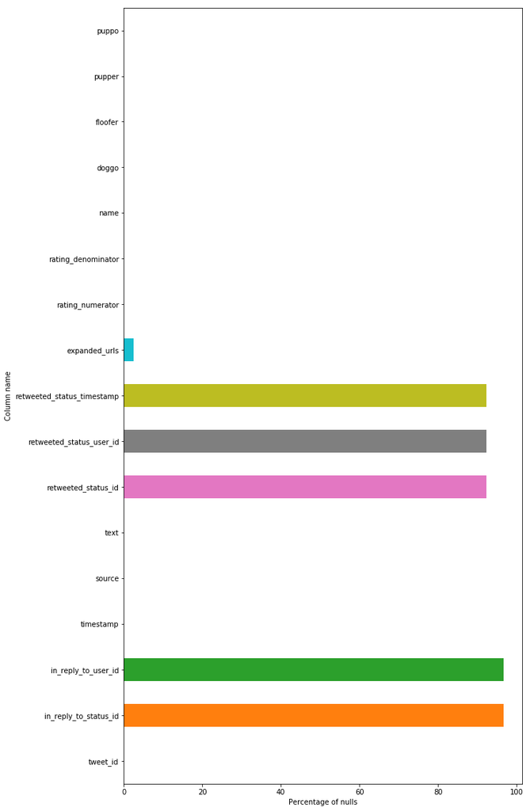

```python
# precentage of missing value.
missing_value.plot.barh(figsize=(10,20));
plt.ylabel('Column name');
plt.xlabel('Percentage of nulls')
```

**in_reply_to_status_id, in_reply_to_user_id, retweeted_status_id, retweeted_status_user_id & retweeted_status_timestamp are missing too much data and should be dropped**

**Observation**

I notice there is missing some ID since in twitter arch is: 2356, image prediction is:2075 & json is 2110.

On the other hand, 'in_reply_to_status_id', 'in_reply_to_user_id', 'retweeted_status_id', 'retweeted_status_user_id', 'retweeted_status_timestamp', are missing more than 80% of data.

**Quality:**

1- source need to be enhanced since it is <a /a>

2- timestamp should be converted to datetime && tweet id to str

3- Delete 'in_reply_to_status_id', 'in_reply_to_user_id', 'retweeted_status_id', 'retweeted_status_user_id', 'retweeted_status_timestamp', since its missing a lot of data

4- There is many names that is not corret such as (a,as..etc) and it should be renames to non

5- Drop duplicate image url

6- Combine p1, p2 & p3 and create dog breed

7- Rating not always correct

8- rename id in json to tweet_id

**Tidiness:**

1- Dog stage

2- Create one master sheet

**Cleaning**

First, make a copy of the data

```python
Master_sheet = twitter_archive_enhanced.copy()
clean_image_prediction = image_prediction.copy()
clean_df_json = df_json.copy()
```

**Define**: rename id to tweet id in json

**code**

```python
clean_df_json.rename(columns = {'id':'tweet_id'}, inplace = True)
clean_df_json.rename(columns = {'retweet_count':'retweet'}, inplace = True)
clean_df_json.rename(columns = {'favorite_count':'favorite'}, inplace = True)
```

**Test**

```python
clean_df_json
```

|  | tweet_id | retweet | favorite |
| --- | --- | --- | --- |
| 0 | 892420643555336193 | 8853 | 39467 |
| 1 | 892177421306343426 | 6514 | 33819 |
| 2 | 891815181378084864 | 4328 | 25461 |
| 3 | 891689557279858688 | 8964 | 42908 |
| 4 | 891327558926688256 | 9774 | 41048 |
| 5 | 891087950875897856 | 3261 | 20562 |
| 6 | 890971913173991426 | 2158 | 12041 |
| 7 | 890729181411237888 | 16716 | 56848 |
| 8 | 890609185150312448 | 4429 | 28226 |
| 9 | 890240255349198849 | 7711 | 32467 |
| 10 | 890006608113172480 | 7624 | 31166 |
| 11 | 889880896479866881 | 5156 | 28268 |
| 12 | 889665388333682689 | 8538 | 38818 |
| 13 | 889638837579907072 | 4735 | 27672 |
| 14 | 889531135344209921 | 2321 | 15359 |
| 15 | 889278841981685760 | 5637 | 25652 |
| 16 | 888917238123831296 | 4709 | 29611 |
| 17 | 888804989199671297 | 4559 | 26080 |
| 18 | 888554962724278272 | 3732 | 20290 |
| 19 | 888078434458587136 | 3653 | 22201 |
| 20 | 887705289381826560 | 5609 | 30779 |
| 21 | 887517139158093824 | 12082 | 46959 |
| 22 | 887473957103951883 | 18781 | 69871 |
| 23 | 887343217045368832 | 10737 | 34222 |
| 24 | 887101392804085760 | 6167 | 31061 |
| 25 | 886983233522544640 | 8084 | 35859 |
| 26 | 886736880519319552 | 3443 | 12306 |
| 27 | 886680336477933568 | 4610 | 22798 |
| 28 | 886366144734445568 | 3316 | 21524 |
| 29 | 886267009285017600 | 4 | 117 |
| ... | ... | ... | ... |
| 2080 | 670815497391357952 | 1708 | 3410 |
| 2081 | 670811965569282048 | 295 | 1202 |
| 2082 | 670807719151067136 | 546 | 1234 |
| 2083 | 670804601705242624 | 1035 | 2098 |
| 2084 | 670803562457407488 | 95 | 362 |
| 2085 | 670797304698376195 | 262 | 780 |
| 2086 | 670792680469889025 | 298 | 889 |
| 2087 | 670789397210615808 | 255 | 700 |
| 2088 | 670786190031921152 | 218 | 640 |
| 2089 | 670783437142401025 | 431 | 872 |
| 2090 | 670782429121134593 | 863 | 1691 |
| 2091 | 670780561024270336 | 317 | 831 |
| 2092 | 670778058496974848 | 77 | 345 |
| 2093 | 670764103623966721 | 466 | 1154 |
| 2094 | 670755717859713024 | 123 | 475 |
| 2095 | 670733412878163972 | 558 | 1030 |
| 2096 | 670727704916926465 | 403 | 887 |
| 2097 | 670717338665226240 | 547 | 1301 |
| 2098 | 670704688707301377 | 405 | 814 |
| 2099 | 670691627984359425 | 266 | 632 |
| 2100 | 670679630144274432 | 315 | 799 |
| 2101 | 670676092097810432 | 45 | 267 |
| 2102 | 670668383499735048 | 5537 | 11452 |
| 2103 | 670474236058800128 | 835 | 1635 |
| 2104 | 670468609693655041 | 90 | 375 |
| 2105 | 670465786746662913 | 608 | 1048 |
| 2106 | 670452855871037440 | 225 | 580 |
| 2107 | 670449342516494336 | 729 | 1264 |
| 2108 | 670444955656130560 | 2153 | 7120 |
| 2109 | 670442337873600512 | 213 | 690 |

2110 rows × 3 columns

**Define** create on master sheet.

**code**

```python
Master_sheet =pd.merge(left=Master_sheet,
                                 right=clean_image_prediction, how='inner')
Master_sheet = Master_sheet.merge(clean_df_json, how='inner')
```

**Test**

```python
Master_sheet.info()
```

```
<class 'pandas.core.frame.DataFrame'>
Int64Index: 1833 entries, 0 to 1832
Data columns (total 30 columns):
tweet_id                      1833 non-null int64
in_reply_to_status_id         22 non-null float64
in_reply_to_user_id           22 non-null float64
timestamp                     1833 non-null object
source                        1833 non-null object
text                          1833 non-null object
retweeted_status_id           77 non-null float64
retweeted_status_user_id      77 non-null float64
retweeted_status_timestamp    77 non-null object
expanded_urls                 1833 non-null object
rating_numerator              1833 non-null int64
rating_denominator            1833 non-null int64
name                          1833 non-null object
doggo                         1833 non-null object
floofer                       1833 non-null object
pupper                        1833 non-null object
puppo                         1833 non-null object
jpg_url                       1833 non-null object
img_num                       1833 non-null int64
p1                            1833 non-null object
p1_conf                       1833 non-null float64
p1_dog                        1833 non-null bool
p2                            1833 non-null object
p2_conf                       1833 non-null float64
p2_dog                        1833 non-null bool
p3                            1833 non-null object
p3_conf                       1833 non-null float64
p3_dog                        1833 non-null bool
retweet                       1833 non-null int64
favorite                      1833 non-null int64
dtypes: bool(3), float64(7), int64(6), object(14)
memory usage: 406.3+ KB
```

**Define**: Clean and enhance the source.

**Code**

```python
Master_sheet['source'] = Master_sheet['source'].apply(lambda x: re.findall(r'>(.*)<', x)[0])
```

**Test**

```python
Master_sheet.head()
```

|  | tweet_id | in_reply_to_status_id | in_reply_to_user_id | timestamp | source | text | retweeted_status_id | retweeted_status_user_id | retweeted_status_timestamp | expanded_urls | ... | p1_conf | p1_dog | p2 | p2_conf | p2_dog | p3 | p3_conf | p3_dog | retweet | favorite |
| --- | --- | --- | --- | --- | --- | --- | --- | --- | --- | --- | --- | --- | --- | --- | --- | --- | --- | --- | --- | --- | --- |
| 0 | 892420643555336193 | NaN | NaN | 2017-08-01 16:23:56 +0000 | Twitter for iPhone | This is Phineas. He's a mystical boy. Only eve... | NaN | NaN | NaN | https://twitter.com/dog_rates/status/892420643... | ... | 0.097049 | False | bagel | 0.085851 | False | banana | 0.076110 | False | 8853 | 39467 |
| 1 | 892177421306343426 | NaN | NaN | 2017-08-01 00:17:27 +0000 | Twitter for iPhone | This is Tilly. She's just checking pup on you.... | NaN | NaN | NaN | https://twitter.com/dog_rates/status/892177421... | ... | 0.323581 | True | Pekinese | 0.090647 | True | papillon | 0.068957 | True | 6514 | 33819 |
| 2 | 891815181378084864 | NaN | NaN | 2017-07-31 00:18:03 +0000 | Twitter for iPhone | This is Archie. He is a rare Norwegian Pouncin... | NaN | NaN | NaN | https://twitter.com/dog_rates/status/891815181... | ... | 0.716012 | True | malamute | 0.078253 | True | kelpie | 0.031379 | True | 4328 | 25461 |
| 3 | 891689557279858688 | NaN | NaN | 2017-07-30 15:58:51 +0000 | Twitter for iPhone | This is Darla. She commenced a snooze mid meal... | NaN | NaN | NaN | https://twitter.com/dog_rates/status/891689557... | ... | 0.170278 | False | Labrador_retriever | 0.168086 | True | spatula | 0.040836 | False | 8964 | 42908 |
| 4 | 891327558926688256 | NaN | NaN | 2017-07-29 16:00:24 +0000 | Twitter for iPhone | This is Franklin. He would like you to stop ca... | NaN | NaN | NaN | https://twitter.com/dog_rates/status/891327558... | ... | 0.555712 | True | English_springer | 0.225770 | True | German_short-haired_pointer | 0.175219 | True | 9774 | 41048 |

5 rows × 30 columns

**Define**: convert the data type

**Code**

```python
Master_sheet['tweet_id'] = Master_sheet['tweet_id'].astype('str')
Master_sheet['timestamp'] = pd.to_datetime(Master_sheet.timestamp)
```

**Test**

```python
Master_sheet.info()
```

```
<class 'pandas.core.frame.DataFrame'>
Int64Index: 1833 entries, 0 to 1832
Data columns (total 30 columns):
tweet_id                      1833 non-null object
in_reply_to_status_id         22 non-null float64
in_reply_to_user_id           22 non-null float64
timestamp                     1833 non-null datetime64[ns]
source                        1833 non-null object
text                          1833 non-null object
retweeted_status_id           77 non-null float64
retweeted_status_user_id      77 non-null float64
retweeted_status_timestamp    77 non-null object
expanded_urls                 1833 non-null object
rating_numerator              1833 non-null int64
rating_denominator            1833 non-null int64
name                          1833 non-null object
doggo                         1833 non-null object
floofer                       1833 non-null object
pupper                        1833 non-null object
puppo                         1833 non-null object
jpg_url                       1833 non-null object
img_num                       1833 non-null int64
p1                            1833 non-null object
p1_conf                       1833 non-null float64
p1_dog                        1833 non-null bool
p2                            1833 non-null object
p2_conf                       1833 non-null float64
p2_dog                        1833 non-null bool
p3                            1833 non-null object
p3_conf                       1833 non-null float64
p3_dog                        1833 non-null bool
retweet                       1833 non-null int64
favorite                      1833 non-null int64
dtypes: bool(3), datetime64[ns](1), float64(7), int64(5), object(14)
memory usage: 406.3+ KB
```

**Define**: drop 'in_reply_to_status_id', 'in_reply_to_user_id', 'retweeted_status_id', 'retweeted_status_user_id', 'retweeted_status_timestamp'

**Code**

```python
Master_sheet.drop(['in_reply_to_status_id', 'in_reply_to_user_id', 'retweeted_status_id', 'retweeted_status_user_id', 'retweeted_status_timestamp'], axis=1, inplace=True)
```

**Test**

```python
Master_sheet.info()
```

```
<class 'pandas.core.frame.DataFrame'>
Int64Index: 1833 entries, 0 to 1832
Data columns (total 25 columns):
tweet_id              1833 non-null object
timestamp             1833 non-null datetime64[ns]
source                1833 non-null object
text                  1833 non-null object
expanded_urls         1833 non-null object
rating_numerator      1833 non-null int64
rating_denominator    1833 non-null int64
name                  1833 non-null object
doggo                 1833 non-null object
floofer               1833 non-null object
pupper                1833 non-null object
puppo                 1833 non-null object
jpg_url               1833 non-null object
img_num               1833 non-null int64
p1                    1833 non-null object
p1_conf               1833 non-null float64
p1_dog                1833 non-null bool
p2                    1833 non-null object
p2_conf               1833 non-null float64
p2_dog                1833 non-null bool
p3                    1833 non-null object
p3_conf               1833 non-null float64
p3_dog                1833 non-null bool
retweet               1833 non-null int64
favorite              1833 non-null int64
dtypes: bool(3), datetime64[ns](1), float64(3), int64(5), object(13)
memory usage: 334.7+ KB
```

**Define**: change the unmeaning names to None

**Code**

```python
Master_sheet["name"].replace({"a": None, "an": None,"this":None,"The":None, "O": None, "AI": None, "his":None, "such":None}, inplace=True)
```

**Test**

```python
Master_sheet
```

|  | tweet_id | timestamp | source | text | expanded_urls | rating_numerator | rating_denominator | name | doggo | floofer | ... | p1_conf | p1_dog | p2 | p2_conf | p2_dog | p3 | p3_conf | p3_dog | retweet | favorite |
| --- | --- | --- | --- | --- | --- | --- | --- | --- | --- | --- | --- | --- | --- | --- | --- | --- | --- | --- | --- | --- | --- |
| 0 | 892420643555336193 | 2017-08-01 16:23:56 | Twitter for iPhone | This is Phineas. He's a mystical boy. Only eve... | https://twitter.com/dog_rates/status/892420643... | 13 | 10 | Phineas | None | None | ... | 0.097049 | False | bagel | 0.085851 | False | banana | 0.076110 | False | 8853 | 39467 |
| 1 | 892177421306343426 | 2017-08-01 00:17:27 | Twitter for iPhone | This is Tilly. She's just checking pup on you.... | https://twitter.com/dog_rates/status/892177421... | 13 | 10 | Tilly | None | None | ... | 0.323581 | True | Pekinese | 0.090647 | True | papillon | 0.068957 | True | 6514 | 33819 |
| 2 | 891815181378084864 | 2017-07-31 00:18:03 | Twitter for iPhone | This is Archie. He is a rare Norwegian Pouncin... | https://twitter.com/dog_rates/status/891815181... | 12 | 10 | Archie | None | None | ... | 0.716012 | True | malamute | 0.078253 | True | kelpie | 0.031379 | True | 4328 | 25461 |
| 3 | 891689557279858688 | 2017-07-30 15:58:51 | Twitter for iPhone | This is Darla. She commenced a snooze mid meal... | https://twitter.com/dog_rates/status/891689557... | 13 | 10 | Darla | None | None | ... | 0.170278 | False | Labrador_retriever | 0.168086 | True | spatula | 0.040836 | False | 8964 | 42908 |
| 4 | 891327558926688256 | 2017-07-29 16:00:24 | Twitter for iPhone | This is Franklin. He would like you to stop ca... | https://twitter.com/dog_rates/status/891327558... | 12 | 10 | Franklin | None | None | ... | 0.555712 | True | English_springer | 0.225770 | True | German_short-haired_pointer | 0.175219 | True | 9774 | 41048 |
| 5 | 891087950875897856 | 2017-07-29 00:08:17 | Twitter for iPhone | Here we have a majestic great white breaching ... | https://twitter.com/dog_rates/status/891087950... | 13 | 10 | None | None | None | ... | 0.425595 | True | Irish_terrier | 0.116317 | True | Indian_elephant | 0.076902 | False | 3261 | 20562 |
| 6 | 890971913173991426 | 2017-07-28 16:27:12 | Twitter for iPhone | Meet Jax. He enjoys ice cream so much he gets ... | https://gofundme.com/ydvmve-surgery-for-jax,ht... | 13 | 10 | Jax | None | None | ... | 0.341703 | True | Border_collie | 0.199287 | True | ice_lolly | 0.193548 | False | 2158 | 12041 |
| 7 | 890729181411237888 | 2017-07-28 00:22:40 | Twitter for iPhone | When you watch your owner call another dog a g... | https://twitter.com/dog_rates/status/890729181... | 13 | 10 | None | None | None | ... | 0.566142 | True | Eskimo_dog | 0.178406 | True | Pembroke | 0.076507 | True | 16716 | 56848 |
| 8 | 890609185150312448 | 2017-07-27 16:25:51 | Twitter for iPhone | This is Zoey. She doesn't want to be one of th... | https://twitter.com/dog_rates/status/890609185... | 13 | 10 | Zoey | None | None | ... | 0.487574 | True | Irish_setter | 0.193054 | True | Chesapeake_Bay_retriever | 0.118184 | True | 4429 | 28226 |
| 9 | 890240255349198849 | 2017-07-26 15:59:51 | Twitter for iPhone | This is Cassie. She is a college pup. Studying... | https://twitter.com/dog_rates/status/890240255... | 14 | 10 | Cassie | doggo | None | ... | 0.511319 | True | Cardigan | 0.451038 | True | Chihuahua | 0.029248 | True | 7711 | 32467 |
| 10 | 890006608113172480 | 2017-07-26 00:31:25 | Twitter for iPhone | This is Koda. He is a South Australian decksha... | https://twitter.com/dog_rates/status/890006608... | 13 | 10 | Koda | None | None | ... | 0.957979 | True | Pomeranian | 0.013884 | True | chow | 0.008167 | True | 7624 | 31166 |
| 11 | 889880896479866881 | 2017-07-25 16:11:53 | Twitter for iPhone | This is Bruno. He is a service shark. Only get... | https://twitter.com/dog_rates/status/889880896... | 13 | 10 | Bruno | None | None | ... | 0.377417 | True | Labrador_retriever | 0.151317 | True | muzzle | 0.082981 | False | 5156 | 28268 |
| 12 | 889665388333682689 | 2017-07-25 01:55:32 | Twitter for iPhone | Here's a puppo that seems to be on the fence a... | https://twitter.com/dog_rates/status/889665388... | 13 | 10 | None | None | None | ... | 0.966327 | True | Cardigan | 0.027356 | True | basenji | 0.004633 | True | 8538 | 38818 |
| 13 | 889638837579907072 | 2017-07-25 00:10:02 | Twitter for iPhone | This is Ted. He does his best. Sometimes that'... | https://twitter.com/dog_rates/status/889638837... | 12 | 10 | Ted | None | None | ... | 0.991650 | True | boxer | 0.002129 | True | Staffordshire_bullterrier | 0.001498 | True | 4735 | 27672 |
| 14 | 889531135344209921 | 2017-07-24 17:02:04 | Twitter for iPhone | This is Stuart. He's sporting his favorite fan... | https://twitter.com/dog_rates/status/889531135... | 13 | 10 | Stuart | None | None | ... | 0.953442 | True | Labrador_retriever | 0.013834 | True | redbone | 0.007958 | True | 2321 | 15359 |
| 15 | 889278841981685760 | 2017-07-24 00:19:32 | Twitter for iPhone | This is Oliver. You're witnessing one of his m... | https://twitter.com/dog_rates/status/889278841... | 13 | 10 | Oliver | None | None | ... | 0.626152 | True | borzoi | 0.194742 | True | Saluki | 0.027351 | True | 5637 | 25652 |
| 16 | 888917238123831296 | 2017-07-23 00:22:39 | Twitter for iPhone | This is Jim. He found a fren. Taught him how t... | https://twitter.com/dog_rates/status/888917238... | 12 | 10 | Jim | None | None | ... | 0.714719 | True | Tibetan_mastiff | 0.120184 | True | Labrador_retriever | 0.105506 | True | 4709 | 29611 |
| 17 | 888804989199671297 | 2017-07-22 16:56:37 | Twitter for iPhone | This is Zeke. He has a new stick. Very proud o... | https://twitter.com/dog_rates/status/888804989... | 13 | 10 | Zeke | None | None | ... | 0.469760 | True | Labrador_retriever | 0.184172 | True | English_setter | 0.073482 | True | 4559 | 26080 |
| 18 | 888554962724278272 | 2017-07-22 00:23:06 | Twitter for iPhone | This is Ralphus. He's powering up. Attempting ... | https://twitter.com/dog_rates/status/888554962... | 13 | 10 | Ralphus | None | None | ... | 0.700377 | True | Eskimo_dog | 0.166511 | True | malamute | 0.111411 | True | 3732 | 20290 |
| 19 | 888078434458587136 | 2017-07-20 16:49:33 | Twitter for iPhone | This is Gerald. He was just told he didn't get... | https://twitter.com/dog_rates/status/888078434... | 12 | 10 | Gerald | None | None | ... | 0.995026 | True | pug | 0.000932 | True | bull_mastiff | 0.000903 | True | 3653 | 22201 |
| 20 | 887705289381826560 | 2017-07-19 16:06:48 | Twitter for iPhone | This is Jeffrey. He has a monopoly on the pool... | https://twitter.com/dog_rates/status/887705289... | 13 | 10 | Jeffrey | None | None | ... | 0.821664 | True | redbone | 0.087582 | True | Weimaraner | 0.026236 | True | 5609 | 30779 |
| 21 | 887517139158093824 | 2017-07-19 03:39:09 | Twitter for iPhone | I've yet to rate a Venezuelan Hover Wiener. Th... | https://twitter.com/dog_rates/status/887517139... | 14 | 10 | None | None | None | ... | 0.130432 | False | tow_truck | 0.029175 | False | shopping_cart | 0.026321 | False | 12082 | 46959 |
| 22 | 887473957103951883 | 2017-07-19 00:47:34 | Twitter for iPhone | This is Canela. She attempted some fancy porch... | https://twitter.com/dog_rates/status/887473957... | 13 | 10 | Canela | None | None | ... | 0.809197 | True | Rhodesian_ridgeback | 0.054950 | True | beagle | 0.038915 | True | 18781 | 69871 |
| 23 | 887343217045368832 | 2017-07-18 16:08:03 | Twitter for iPhone | You may not have known you needed to see this ... | https://twitter.com/dog_rates/status/887343217... | 13 | 10 | None | None | None | ... | 0.330741 | True | sea_lion | 0.275645 | False | Weimaraner | 0.134203 | True | 10737 | 34222 |
| 24 | 887101392804085760 | 2017-07-18 00:07:08 | Twitter for iPhone | This... is a Jubilant Antarctic House Bear. We... | https://twitter.com/dog_rates/status/887101392... | 12 | 10 | None | None | None | ... | 0.733942 | True | Eskimo_dog | 0.035029 | True | Staffordshire_bullterrier | 0.029705 | True | 6167 | 31061 |
| 25 | 886983233522544640 | 2017-07-17 16:17:36 | Twitter for iPhone | This is Maya. She's very shy. Rarely leaves he... | https://twitter.com/dog_rates/status/886983233... | 13 | 10 | Maya | None | None | ... | 0.793469 | True | toy_terrier | 0.143528 | True | can_opener | 0.032253 | False | 8084 | 35859 |
| 26 | 886736880519319552 | 2017-07-16 23:58:41 | Twitter for iPhone | This is Mingus. He's a wonderful father to his... | https://www.gofundme.com/mingusneedsus,https:/... | 13 | 10 | Mingus | None | None | ... | 0.309706 | True | Great_Pyrenees | 0.186136 | True | Dandie_Dinmont | 0.086346 | True | 3443 | 12306 |
| 27 | 886680336477933568 | 2017-07-16 20:14:00 | Twitter for iPhone | This is Derek. He's late for a dog meeting. 13... | https://twitter.com/dog_rates/status/886680336... | 13 | 10 | Derek | None | None | ... | 0.738995 | False | sports_car | 0.139952 | False | car_wheel | 0.044173 | False | 4610 | 22798 |
| 28 | 886366144734445568 | 2017-07-15 23:25:31 | Twitter for iPhone | This is Roscoe. Another pupper fallen victim t... | https://twitter.com/dog_rates/status/886366144... | 12 | 10 | Roscoe | None | None | ... | 0.999201 | True | Chihuahua | 0.000361 | True | Boston_bull | 0.000076 | True | 3316 | 21524 |
| 29 | 886258384151887873 | 2017-07-15 16:17:19 | Twitter for iPhone | This is Waffles. His doggles are pupside down.... | https://twitter.com/dog_rates/status/886258384... | 13 | 10 | Waffles | None | None | ... | 0.943575 | True | shower_cap | 0.025286 | False | Siamese_cat | 0.002849 | False | 6523 | 28469 |
| ... | ... | ... | ... | ... | ... | ... | ... | ... | ... | ... | ... | ... | ... | ... | ... | ... | ... | ... | ... | ... | ... |
| 1803 | 670815497391357952 | 2015-11-29 04:04:12 | Twitter for iPhone | This is Sage. He likes to burn shit. 10/10 htt... | https://twitter.com/dog_rates/status/670815497... | 10 | 10 | Sage | None | None | ... | 0.919714 | True | Staffordshire_bullterrier | 0.073430 | True | bull_mastiff | 0.000906 | True | 1708 | 3410 |
| 1804 | 670811965569282048 | 2015-11-29 03:50:10 | Twitter for iPhone | Meet Maggie. She enjoys her stick in the yard.... | https://twitter.com/dog_rates/status/670811965... | 10 | 10 | Maggie | None | None | ... | 0.994090 | True | Walker_hound | 0.003973 | True | beagle | 0.001406 | True | 295 | 1202 |
| 1805 | 670807719151067136 | 2015-11-29 03:33:17 | Twitter for iPhone | Say hello to Andy. He can balance on one foot,... | https://twitter.com/dog_rates/status/670807719... | 11 | 10 | Andy | None | None | ... | 0.958035 | True | Sealyham_terrier | 0.013892 | True | Border_collie | 0.004601 | True | 546 | 1234 |
| 1806 | 670804601705242624 | 2015-11-29 03:20:54 | Twitter for iPhone | Meet Mason. He's a total frat boy. Pretends to... | https://twitter.com/dog_rates/status/670804601... | 10 | 10 | Mason | None | None | ... | 0.868560 | True | Pekinese | 0.090129 | True | chow | 0.021722 | True | 1035 | 2098 |
| 1807 | 670803562457407488 | 2015-11-29 03:16:46 | Twitter for iPhone | I would do radical things in the name of Dog G... | https://twitter.com/dog_rates/status/670803562... | 10 | 10 | None | None | None | ... | 0.344101 | True | Ibizan_hound | 0.210282 | True | toy_terrier | 0.196279 | True | 95 | 362 |
| 1808 | 670797304698376195 | 2015-11-29 02:51:54 | Twitter for iPhone | This is Trigger. He was minding his own busine... | https://twitter.com/dog_rates/status/670797304... | 11 | 10 | Trigger | None | None | ... | 0.472197 | True | beagle | 0.090938 | True | German_shepherd | 0.064366 | True | 262 | 780 |
| 1809 | 670792680469889025 | 2015-11-29 02:33:32 | Twitter for iPhone | This is Antony. He's a Sheraton Tetrahedron. S... | https://twitter.com/dog_rates/status/670792680... | 7 | 10 | Antony | None | None | ... | 0.882426 | False | toy_poodle | 0.031355 | True | miniature_poodle | 0.025743 | True | 298 | 889 |
| 1810 | 670789397210615808 | 2015-11-29 02:20:29 | Twitter for iPhone | Two obedient dogs here. Left one has extra leg... | https://twitter.com/dog_rates/status/670789397... | 9 | 10 | None | None | None | ... | 0.295966 | True | basset | 0.143527 | True | bluetick | 0.138992 | True | 255 | 700 |
| 1811 | 670786190031921152 | 2015-11-29 02:07:44 | Twitter for iPhone | This is Creg. You offered him a ride to work b... | https://twitter.com/dog_rates/status/670786190... | 8 | 10 | Creg | None | None | ... | 0.777124 | False | Pembroke | 0.127438 | True | Cardigan | 0.024007 | True | 218 | 640 |
| 1812 | 670783437142401025 | 2015-11-29 01:56:48 | Twitter for iPhone | Flamboyant pup here. Probably poisonous. Won't... | https://twitter.com/dog_rates/status/670783437... | 1 | 10 | None | None | None | ... | 0.381955 | False | sulphur_butterfly | 0.106810 | False | leafhopper | 0.068347 | False | 431 | 872 |
| 1813 | 670782429121134593 | 2015-11-29 01:52:48 | Twitter for iPhone | This dude slaps your girl's ass what do you do... | https://twitter.com/dog_rates/status/670782429... | 5 | 10 | None | None | None | ... | 0.952963 | True | French_bulldog | 0.036575 | True | Boston_bull | 0.001977 | True | 863 | 1691 |
| 1814 | 670780561024270336 | 2015-11-29 01:45:22 | Twitter for iPhone | This is Traviss. He has no ears. Two rare dogs... | https://twitter.com/dog_rates/status/670780561... | 7 | 10 | Traviss | None | None | ... | 0.244889 | True | American_black_bear | 0.056994 | False | brown_bear | 0.053993 | False | 317 | 831 |
| 1815 | 670778058496974848 | 2015-11-29 01:35:26 | Twitter for iPhone | "To bone or not to bone?"\n10/10 https://t.co/... | https://twitter.com/dog_rates/status/670778058... | 10 | 10 | None | None | None | ... | 0.776612 | True | Brabancon_griffon | 0.112032 | True | boxer | 0.039051 | True | 77 | 345 |
| 1816 | 670764103623966721 | 2015-11-29 00:39:59 | Twitter for iPhone | Meet Vincent. He's a wild Adderall Cayenne. Sh... | https://twitter.com/dog_rates/status/670764103... | 10 | 10 | Vincent | None | None | ... | 0.172850 | True | golden_retriever | 0.072702 | True | television | 0.037494 | False | 466 | 1154 |
| 1817 | 670755717859713024 | 2015-11-29 00:06:39 | Twitter for iPhone | Say hello to Gin &amp; Tonic. They're having a... | https://twitter.com/dog_rates/status/670755717... | 9 | 10 | Gin | None | None | ... | 0.994065 | True | Norwegian_elkhound | 0.001827 | True | cairn | 0.001821 | True | 123 | 475 |
| 1818 | 670733412878163972 | 2015-11-28 22:38:01 | Twitter for iPhone | This is Jerry. He's a great listener. Low main... | https://twitter.com/dog_rates/status/670733412... | 8 | 10 | Jerry | None | None | ... | 0.350416 | False | hare | 0.236661 | False | wood_rabbit | 0.091133 | False | 558 | 1030 |
| 1819 | 670727704916926465 | 2015-11-28 22:15:21 | Twitter for iPhone | This is Jeffrie. He's a handheld pup. Excellen... | https://twitter.com/dog_rates/status/670727704... | 10 | 10 | Jeffrie | None | None | ... | 0.368562 | False | tabby | 0.309675 | False | Egyptian_cat | 0.154914 | False | 403 | 887 |
| 1820 | 670717338665226240 | 2015-11-28 21:34:09 | Twitter for iPhone | *screams for a little bit and then crumples to... | https://twitter.com/dog_rates/status/670717338... | 12 | 10 | None | None | None | ... | 0.368161 | True | Pekinese | 0.350973 | True | golden_retriever | 0.114902 | True | 547 | 1301 |
| 1821 | 670704688707301377 | 2015-11-28 20:43:53 | Twitter for iPhone | Meet Danny. He's too good to look at the road ... | https://twitter.com/dog_rates/status/670704688... | 6 | 10 | Danny | None | None | ... | 0.419838 | True | cairn | 0.351876 | True | Norfolk_terrier | 0.051094 | True | 405 | 814 |
| 1822 | 670691627984359425 | 2015-11-28 19:51:59 | Twitter for iPhone | This is Ester. He has a cocaine problem. This ... | https://twitter.com/dog_rates/status/670691627... | 8 | 10 | Ester | None | None | ... | 0.071124 | True | home_theater | 0.068398 | False | American_Staffordshire_terrier | 0.066964 | True | 266 | 632 |
| 1823 | 670679630144274432 | 2015-11-28 19:04:19 | Twitter for iPhone | This is Pluto. He's holding little waddling do... | https://twitter.com/dog_rates/status/670679630... | 8 | 10 | Pluto | None | None | ... | 0.342734 | True | Brittany_spaniel | 0.229065 | True | Chihuahua | 0.104029 | True | 315 | 799 |
| 1824 | 670676092097810432 | 2015-11-28 18:50:15 | Twitter for iPhone | This is Bloo. He's a Westminster Cîroc. Doesn'... | https://twitter.com/dog_rates/status/670676092... | 8 | 10 | Bloo | None | None | ... | 0.676102 | True | West_Highland_white_terrier | 0.040826 | True | clumber | 0.039533 | True | 45 | 267 |
| 1825 | 670668383499735048 | 2015-11-28 18:19:37 | Twitter for iPhone | This is Phineas. He's a magical dog. Only appe... | https://twitter.com/dog_rates/status/670668383... | 10 | 10 | Phineas | None | None | ... | 0.107317 | False | orange | 0.099662 | False | bagel | 0.089033 | False | 5537 | 11452 |
| 1826 | 670474236058800128 | 2015-11-28 05:28:09 | Twitter for iPhone | Honor to rate this dog. Great teeth. Nice horn... | https://twitter.com/dog_rates/status/670474236... | 10 | 10 | None | None | None | ... | 0.070076 | False | siamang | 0.062536 | False | gorilla | 0.058894 | False | 835 | 1635 |
| 1827 | 670468609693655041 | 2015-11-28 05:05:47 | Twitter for iPhone | This is Edd. He's a Czechoslovakian Googolplex... | https://twitter.com/dog_rates/status/670468609... | 10 | 10 | Edd | None | None | ... | 0.730152 | False | beach_wagon | 0.078661 | False | car_wheel | 0.064346 | False | 90 | 375 |
| 1828 | 670465786746662913 | 2015-11-28 04:54:34 | Twitter for iPhone | Silly dog here. Wearing bunny ears. Nice long ... | https://twitter.com/dog_rates/status/670465786... | 7 | 10 | None | None | None | ... | 0.611558 | False | tailed_frog | 0.186484 | False | common_newt | 0.078694 | False | 608 | 1048 |
| 1829 | 670452855871037440 | 2015-11-28 04:03:11 | Twitter for iPhone | This dog can't see its haters. 11/10 https://t... | https://twitter.com/dog_rates/status/670452855... | 11 | 10 | None | None | None | ... | 0.188174 | False | indri | 0.123584 | False | malamute | 0.080379 | True | 225 | 580 |
| 1830 | 670449342516494336 | 2015-11-28 03:49:14 | Twitter for iPhone | Vibrant dog here. Fabulous tail. Only 2 legs t... | https://twitter.com/dog_rates/status/670449342... | 5 | 10 | None | None | None | ... | 0.999924 | False | European_gallinule | 0.000030 | False | agama | 0.000022 | False | 729 | 1264 |
| 1831 | 670444955656130560 | 2015-11-28 03:31:48 | Twitter for iPhone | This is Paull. He just stubbed his toe. 10/10 ... | https://twitter.com/dog_rates/status/670444955... | 10 | 10 | Paull | None | None | ... | 0.403698 | True | Brittany_spaniel | 0.347609 | True | Welsh_springer_spaniel | 0.137186 | True | 2153 | 7120 |
| 1832 | 670442337873600512 | 2015-11-28 03:21:24 | Twitter for iPhone | Meet Koda. He's large. Looks very soft. Great ... | https://twitter.com/dog_rates/status/670442337... | 11 | 10 | Koda | None | None | ... | 0.403552 | True | otterhound | 0.256302 | True | Irish_terrier | 0.187315 | True | 213 | 690 |

1833 rows × 25 columns

**Define:** Drop duplicate image url

**Code**

```python
Master_sheet = Master_sheet.drop_duplicates(subset=['jpg_url'], keep='last')
```

**Test**

```python
sum(Master_sheet['jpg_url'].duplicated())
```

```
0
```

**Define:** Combine p1,p2& p3

**Code**

```python
def dog_breed(row):
    if row['p1_dog']:
        return row['p1']
    elif row['p2_dog']:
        return row['p2']
    elif row['p3_dog']:
        return row['p3']
    else:
        return np.nan

Master_sheet['dog_breed'] = Master_sheet.apply(dog_breed, axis = 1)

# Drop extra columns
Master_sheet = Master_sheet.drop(['img_num', 'p1', 'p1_conf', 'p1_dog', 'p2', 'p2_conf', 'p2_dog', 'p3', 'p3_conf', 'p3_dog'], 1)
```

**Test**

```python
Master_sheet.info()
```

```
<class 'pandas.core.frame.DataFrame'>
Int64Index: 1770 entries, 0 to 1832
Data columns (total 16 columns):
tweet_id              1770 non-null object
timestamp             1770 non-null datetime64[ns]
source                1770 non-null object
text                  1770 non-null object
expanded_urls         1770 non-null object
rating_numerator      1770 non-null int64
rating_denominator    1770 non-null int64
name                  1737 non-null object
doggo                 1770 non-null object
floofer               1770 non-null object
pupper                1770 non-null object
puppo                 1770 non-null object
jpg_url               1770 non-null object
retweet               1770 non-null int64
favorite              1770 non-null int64
dog_breed             1508 non-null object
dtypes: datetime64[ns](1), int64(4), object(11)
memory usage: 235.1+ KB
```

**Code**

```python
Master_sheet.rating_denominator= Master_sheet['rating_denominator']=10
```

**Test**

```python
Master_sheet.head()
```

|  | tweet_id | timestamp | source | text | expanded_urls | rating_numerator | rating_denominator | name | doggo | floofer | pupper | puppo | jpg_url | retweet | favorite | dog_breed |
| --- | --- | --- | --- | --- | --- | --- | --- | --- | --- | --- | --- | --- | --- | --- | --- | --- |
| 0 | 892420643555336193 | 2017-08-01 16:23:56 | Twitter for iPhone | This is Phineas. He's a mystical boy. Only eve... | https://twitter.com/dog_rates/status/892420643... | 13 | 10 | Phineas | None | None | None | None | https://pbs.twimg.com/media/DGKD1-bXoAAIAUK.jpg | 8853 | 39467 | NaN |
| 1 | 892177421306343426 | 2017-08-01 00:17:27 | Twitter for iPhone | This is Tilly. She's just checking pup on you.... | https://twitter.com/dog_rates/status/892177421... | 13 | 10 | Tilly | None | None | None | None | https://pbs.twimg.com/media/DGGmoV4XsAAUL6n.jpg | 6514 | 33819 | Chihuahua |
| 2 | 891815181378084864 | 2017-07-31 00:18:03 | Twitter for iPhone | This is Archie. He is a rare Norwegian Pouncin... | https://twitter.com/dog_rates/status/891815181... | 12 | 10 | Archie | None | None | None | None | https://pbs.twimg.com/media/DGBdLU1WsAANxJ9.jpg | 4328 | 25461 | Chihuahua |
| 3 | 891689557279858688 | 2017-07-30 15:58:51 | Twitter for iPhone | This is Darla. She commenced a snooze mid meal... | https://twitter.com/dog_rates/status/891689557... | 13 | 10 | Darla | None | None | None | None | https://pbs.twimg.com/media/DF_q7IAWsAEuuN8.jpg | 8964 | 42908 | Labrador_retriever |
| 4 | 891327558926688256 | 2017-07-29 16:00:24 | Twitter for iPhone | This is Franklin. He would like you to stop ca... | https://twitter.com/dog_rates/status/891327558... | 12 | 10 | Franklin | None | None | None | None | https://pbs.twimg.com/media/DF6hr6BUMAAzZgT.jpg | 9774 | 41048 | basset |

**Define:** dog style

**Code**

```python
#Master_sheet['dog_stage'] = Master_sheet['text'].str.extract('(puppo|pupper|floofer|doggo)', expand=True)

# Drop 'doggo', 'floofer', 'pupper', 'puppo' columns
#Master_sheet = Master_sheet.drop(columns = ['doggo', 'floofer', 'pupper', 'puppo'])
#stage = []
#def dog_stage(row):

#    if row['doggo'] == 'doggo':
#        stage.append('doggo')
#    if row['floofer'] == 'floofer':
#        stage.append('floofer')
#    if row['pupper'] == 'pupper':
#        stage.append('pupper')
#    if row['puppo'] == 'puppo':
#        stage.append('puppo')

#    if not stage:
#        return "None"
#    else:
#        return ','.join(stage)

#Master_sheet['dog_stage'] = Master_sheet.apply(lambda row: dog_stage(row), axis=1)

# drop the columns
#Master_sheet.drop(["doggo", "floofer", "pupper", "puppo"], axis=1, inplace=True)

Master_sheet.loc[Master_sheet['doggo'] == 'doggo', 'dog_stage'] = 'doggo'
Master_sheet.loc[Master_sheet['floofer'] == 'floofer', 'dog_stage'] = 'floofer'
Master_sheet.loc[Master_sheet['pupper'] == 'pupper', 'dog_stage'] = 'pupper'
Master_sheet.loc[Master_sheet['puppo'] == 'puppo', 'dog_stage'] = 'puppo'

# dropping unneded doggo, floofer, pupper or poppo columns
Master_sheet = Master_sheet.drop(['doggo', 'floofer', 'pupper', 'puppo'], axis = 1)
```

**Test**

```python
pd.value_counts(Master_sheet['dog_stage'])
```

```
pupper     215
doggo       63
puppo       23
floofer      8
Name: dog_stage, dtype: int64
```

```python
Master_sheet
```

|  | tweet_id | timestamp | source | text | expanded_urls | rating_numerator | rating_denominator | name | jpg_url | retweet | favorite | dog_breed | dog_stage |
| --- | --- | --- | --- | --- | --- | --- | --- | --- | --- | --- | --- | --- | --- |
| 0 | 892420643555336193 | 2017-08-01 16:23:56 | Twitter for iPhone | This is Phineas. He's a mystical boy. Only eve... | https://twitter.com/dog_rates/status/892420643... | 13 | 10 | Phineas | https://pbs.twimg.com/media/DGKD1-bXoAAIAUK.jpg | 8853 | 39467 | NaN | NaN |
| 1 | 892177421306343426 | 2017-08-01 00:17:27 | Twitter for iPhone | This is Tilly. She's just checking pup on you.... | https://twitter.com/dog_rates/status/892177421... | 13 | 10 | Tilly | https://pbs.twimg.com/media/DGGmoV4XsAAUL6n.jpg | 6514 | 33819 | Chihuahua | NaN |
| 2 | 891815181378084864 | 2017-07-31 00:18:03 | Twitter for iPhone | This is Archie. He is a rare Norwegian Pouncin... | https://twitter.com/dog_rates/status/891815181... | 12 | 10 | Archie | https://pbs.twimg.com/media/DGBdLU1WsAANxJ9.jpg | 4328 | 25461 | Chihuahua | NaN |
| 3 | 891689557279858688 | 2017-07-30 15:58:51 | Twitter for iPhone | This is Darla. She commenced a snooze mid meal... | https://twitter.com/dog_rates/status/891689557... | 13 | 10 | Darla | https://pbs.twimg.com/media/DF_q7IAWsAEuuN8.jpg | 8964 | 42908 | Labrador_retriever | NaN |
| 4 | 891327558926688256 | 2017-07-29 16:00:24 | Twitter for iPhone | This is Franklin. He would like you to stop ca... | https://twitter.com/dog_rates/status/891327558... | 12 | 10 | Franklin | https://pbs.twimg.com/media/DF6hr6BUMAAzZgT.jpg | 9774 | 41048 | basset | NaN |
| 5 | 891087950875897856 | 2017-07-29 00:08:17 | Twitter for iPhone | Here we have a majestic great white breaching ... | https://twitter.com/dog_rates/status/891087950... | 13 | 10 | None | https://pbs.twimg.com/media/DF3HwyEWsAABqE6.jpg | 3261 | 20562 | Chesapeake_Bay_retriever | NaN |
| 6 | 890971913173991426 | 2017-07-28 16:27:12 | Twitter for iPhone | Meet Jax. He enjoys ice cream so much he gets ... | https://gofundme.com/ydvmve-surgery-for-jax,ht... | 13 | 10 | Jax | https://pbs.twimg.com/media/DF1eOmZXUAALUcq.jpg | 2158 | 12041 | Appenzeller | NaN |
| 7 | 890729181411237888 | 2017-07-28 00:22:40 | Twitter for iPhone | When you watch your owner call another dog a g... | https://twitter.com/dog_rates/status/890729181... | 13 | 10 | None | https://pbs.twimg.com/media/DFyBahAVwAAhUTd.jpg | 16716 | 56848 | Pomeranian | NaN |
| 8 | 890609185150312448 | 2017-07-27 16:25:51 | Twitter for iPhone | This is Zoey. She doesn't want to be one of th... | https://twitter.com/dog_rates/status/890609185... | 13 | 10 | Zoey | https://pbs.twimg.com/media/DFwUU__XcAEpyXI.jpg | 4429 | 28226 | Irish_terrier | NaN |
| 9 | 890240255349198849 | 2017-07-26 15:59:51 | Twitter for iPhone | This is Cassie. She is a college pup. Studying... | https://twitter.com/dog_rates/status/890240255... | 14 | 10 | Cassie | https://pbs.twimg.com/media/DFrEyVuW0AAO3t9.jpg | 7711 | 32467 | Pembroke | doggo |
| 10 | 890006608113172480 | 2017-07-26 00:31:25 | Twitter for iPhone | This is Koda. He is a South Australian decksha... | https://twitter.com/dog_rates/status/890006608... | 13 | 10 | Koda | https://pbs.twimg.com/media/DFnwSY4WAAAMliS.jpg | 7624 | 31166 | Samoyed | NaN |
| 11 | 889880896479866881 | 2017-07-25 16:11:53 | Twitter for iPhone | This is Bruno. He is a service shark. Only get... | https://twitter.com/dog_rates/status/889880896... | 13 | 10 | Bruno | https://pbs.twimg.com/media/DFl99B1WsAITKsg.jpg | 5156 | 28268 | French_bulldog | NaN |
| 12 | 889665388333682689 | 2017-07-25 01:55:32 | Twitter for iPhone | Here's a puppo that seems to be on the fence a... | https://twitter.com/dog_rates/status/889665388... | 13 | 10 | None | https://pbs.twimg.com/media/DFi579UWsAAatzw.jpg | 8538 | 38818 | Pembroke | puppo |
| 13 | 889638837579907072 | 2017-07-25 00:10:02 | Twitter for iPhone | This is Ted. He does his best. Sometimes that'... | https://twitter.com/dog_rates/status/889638837... | 12 | 10 | Ted | https://pbs.twimg.com/media/DFihzFfXsAYGDPR.jpg | 4735 | 27672 | French_bulldog | NaN |
| 14 | 889531135344209921 | 2017-07-24 17:02:04 | Twitter for iPhone | This is Stuart. He's sporting his favorite fan... | https://twitter.com/dog_rates/status/889531135... | 13 | 10 | Stuart | https://pbs.twimg.com/media/DFg_2PVW0AEHN3p.jpg | 2321 | 15359 | golden_retriever | puppo |
| 15 | 889278841981685760 | 2017-07-24 00:19:32 | Twitter for iPhone | This is Oliver. You're witnessing one of his m... | https://twitter.com/dog_rates/status/889278841... | 13 | 10 | Oliver | https://pbs.twimg.com/ext_tw_video_thumb/88927... | 5637 | 25652 | whippet | NaN |
| 16 | 888917238123831296 | 2017-07-23 00:22:39 | Twitter for iPhone | This is Jim. He found a fren. Taught him how t... | https://twitter.com/dog_rates/status/888917238... | 12 | 10 | Jim | https://pbs.twimg.com/media/DFYRgsOUQAARGhO.jpg | 4709 | 29611 | golden_retriever | NaN |
| 17 | 888804989199671297 | 2017-07-22 16:56:37 | Twitter for iPhone | This is Zeke. He has a new stick. Very proud o... | https://twitter.com/dog_rates/status/888804989... | 13 | 10 | Zeke | https://pbs.twimg.com/media/DFWra-3VYAA2piG.jpg | 4559 | 26080 | golden_retriever | NaN |
| 18 | 888554962724278272 | 2017-07-22 00:23:06 | Twitter for iPhone | This is Ralphus. He's powering up. Attempting ... | https://twitter.com/dog_rates/status/888554962... | 13 | 10 | Ralphus | https://pbs.twimg.com/media/DFTH_O-UQAACu20.jpg | 3732 | 20290 | Siberian_husky | NaN |
| 19 | 888078434458587136 | 2017-07-20 16:49:33 | Twitter for iPhone | This is Gerald. He was just told he didn't get... | https://twitter.com/dog_rates/status/888078434... | 12 | 10 | Gerald | https://pbs.twimg.com/media/DFMWn56WsAAkA7B.jpg | 3653 | 22201 | French_bulldog | NaN |
| 20 | 887705289381826560 | 2017-07-19 16:06:48 | Twitter for iPhone | This is Jeffrey. He has a monopoly on the pool... | https://twitter.com/dog_rates/status/887705289... | 13 | 10 | Jeffrey | https://pbs.twimg.com/media/DFHDQBbXgAEqY7t.jpg | 5609 | 30779 | basset | NaN |
| 21 | 887517139158093824 | 2017-07-19 03:39:09 | Twitter for iPhone | I've yet to rate a Venezuelan Hover Wiener. Th... | https://twitter.com/dog_rates/status/887517139... | 14 | 10 | None | https://pbs.twimg.com/ext_tw_video_thumb/88751... | 12082 | 46959 | NaN | NaN |
| 22 | 887473957103951883 | 2017-07-19 00:47:34 | Twitter for iPhone | This is Canela. She attempted some fancy porch... | https://twitter.com/dog_rates/status/887473957... | 13 | 10 | Canela | https://pbs.twimg.com/media/DFDw2tyUQAAAFke.jpg | 18781 | 69871 | Pembroke | NaN |
| 23 | 887343217045368832 | 2017-07-18 16:08:03 | Twitter for iPhone | You may not have known you needed to see this ... | https://twitter.com/dog_rates/status/887343217... | 13 | 10 | None | https://pbs.twimg.com/ext_tw_video_thumb/88734... | 10737 | 34222 | Mexican_hairless | NaN |
| 24 | 887101392804085760 | 2017-07-18 00:07:08 | Twitter for iPhone | This... is a Jubilant Antarctic House Bear. We... | https://twitter.com/dog_rates/status/887101392... | 12 | 10 | None | https://pbs.twimg.com/media/DE-eAq6UwAA-jaE.jpg | 6167 | 31061 | Samoyed | NaN |
| 25 | 886983233522544640 | 2017-07-17 16:17:36 | Twitter for iPhone | This is Maya. She's very shy. Rarely leaves he... | https://twitter.com/dog_rates/status/886983233... | 13 | 10 | Maya | https://pbs.twimg.com/media/DE8yicJW0AAAvBJ.jpg | 8084 | 35859 | Chihuahua | NaN |
| 26 | 886736880519319552 | 2017-07-16 23:58:41 | Twitter for iPhone | This is Mingus. He's a wonderful father to his... | https://www.gofundme.com/mingusneedsus,https:/... | 13 | 10 | Mingus | https://pbs.twimg.com/media/DE5Se8FXcAAJFx4.jpg | 3443 | 12306 | kuvasz | NaN |
| 27 | 886680336477933568 | 2017-07-16 20:14:00 | Twitter for iPhone | This is Derek. He's late for a dog meeting. 13... | https://twitter.com/dog_rates/status/886680336... | 13 | 10 | Derek | https://pbs.twimg.com/media/DE4fEDzWAAAyHMM.jpg | 4610 | 22798 | NaN | NaN |
| 28 | 886366144734445568 | 2017-07-15 23:25:31 | Twitter for iPhone | This is Roscoe. Another pupper fallen victim t... | https://twitter.com/dog_rates/status/886366144... | 12 | 10 | Roscoe | https://pbs.twimg.com/media/DE0BTnQUwAApKEH.jpg | 3316 | 21524 | French_bulldog | pupper |
| 29 | 886258384151887873 | 2017-07-15 16:17:19 | Twitter for iPhone | This is Waffles. His doggles are pupside down.... | https://twitter.com/dog_rates/status/886258384... | 13 | 10 | Waffles | https://pbs.twimg.com/media/DEyfTG4UMAE4aE9.jpg | 6523 | 28469 | pug | NaN |
| ... | ... | ... | ... | ... | ... | ... | ... | ... | ... | ... | ... | ... | ... |
| 1803 | 670815497391357952 | 2015-11-29 04:04:12 | Twitter for iPhone | This is Sage. He likes to burn shit. 10/10 htt... | https://twitter.com/dog_rates/status/670815497... | 10 | 10 | Sage | https://pbs.twimg.com/media/CU83IZ8W4AEIh4y.jpg | 1708 | 3410 | American_Staffordshire_terrier | NaN |
| 1804 | 670811965569282048 | 2015-11-29 03:50:10 | Twitter for iPhone | Meet Maggie. She enjoys her stick in the yard.... | https://twitter.com/dog_rates/status/670811965... | 10 | 10 | Maggie | https://pbs.twimg.com/media/CU8z65IUEAQBc4q.jpg | 295 | 1202 | basset | NaN |
| 1805 | 670807719151067136 | 2015-11-29 03:33:17 | Twitter for iPhone | Say hello to Andy. He can balance on one foot,... | https://twitter.com/dog_rates/status/670807719... | 11 | 10 | Andy | https://pbs.twimg.com/media/CU8v-rdXIAId12Z.jpg | 546 | 1234 | Old_English_sheepdog | NaN |
| 1806 | 670804601705242624 | 2015-11-29 03:20:54 | Twitter for iPhone | Meet Mason. He's a total frat boy. Pretends to... | https://twitter.com/dog_rates/status/670804601... | 10 | 10 | Mason | https://pbs.twimg.com/media/CU8tOJZWUAAlNoF.jpg | 1035 | 2098 | Pomeranian | NaN |
| 1807 | 670803562457407488 | 2015-11-29 03:16:46 | Twitter for iPhone | I would do radical things in the name of Dog G... | https://twitter.com/dog_rates/status/670803562... | 10 | 10 | None | https://pbs.twimg.com/media/CU8sSAvXIAAB1Py.jpg | 95 | 362 | basenji | NaN |
| 1808 | 670797304698376195 | 2015-11-29 02:51:54 | Twitter for iPhone | This is Trigger. He was minding his own busine... | https://twitter.com/dog_rates/status/670797304... | 11 | 10 | Trigger | https://pbs.twimg.com/media/CU8mlhoVAAAteS5.jpg | 262 | 780 | Pembroke | NaN |
| 1809 | 670792680469889025 | 2015-11-29 02:33:32 | Twitter for iPhone | This is Antony. He's a Sheraton Tetrahedron. S... | https://twitter.com/dog_rates/status/670792680... | 7 | 10 | Antony | https://pbs.twimg.com/media/CU8iYi2WsAEaqQ0.jpg | 298 | 889 | toy_poodle | NaN |
| 1810 | 670789397210615808 | 2015-11-29 02:20:29 | Twitter for iPhone | Two obedient dogs here. Left one has extra leg... | https://twitter.com/dog_rates/status/670789397... | 9 | 10 | None | https://pbs.twimg.com/media/CU8fZSQWoAEVp6O.jpg | 255 | 700 | beagle | NaN |
| 1811 | 670786190031921152 | 2015-11-29 02:07:44 | Twitter for iPhone | This is Creg. You offered him a ride to work b... | https://twitter.com/dog_rates/status/670786190... | 8 | 10 | Creg | https://pbs.twimg.com/media/CU8ceuxWUAALMEo.jpg | 218 | 640 | Pembroke | NaN |
| 1812 | 670783437142401025 | 2015-11-29 01:56:48 | Twitter for iPhone | Flamboyant pup here. Probably poisonous. Won't... | https://twitter.com/dog_rates/status/670783437... | 1 | 10 | None | https://pbs.twimg.com/media/CU8Z-OxXAAA-sd2.jpg | 431 | 872 | NaN | NaN |
| 1813 | 670782429121134593 | 2015-11-29 01:52:48 | Twitter for iPhone | This dude slaps your girl's ass what do you do... | https://twitter.com/dog_rates/status/670782429... | 5 | 10 | None | https://pbs.twimg.com/media/CU8ZDu9WwAADg3N.jpg | 863 | 1691 | Chihuahua | NaN |
| 1814 | 670780561024270336 | 2015-11-29 01:45:22 | Twitter for iPhone | This is Traviss. He has no ears. Two rare dogs... | https://twitter.com/dog_rates/status/670780561... | 7 | 10 | Traviss | https://pbs.twimg.com/media/CU8XW2dWwAA-Lmc.jpg | 317 | 831 | Labrador_retriever | NaN |
| 1815 | 670778058496974848 | 2015-11-29 01:35:26 | Twitter for iPhone | "To bone or not to bone?"\n10/10 https://t.co/... | https://twitter.com/dog_rates/status/670778058... | 10 | 10 | None | https://pbs.twimg.com/media/CU8VFhuVAAAQW8B.jpg | 77 | 345 | pug | NaN |
| 1816 | 670764103623966721 | 2015-11-29 00:39:59 | Twitter for iPhone | Meet Vincent. He's a wild Adderall Cayenne. Sh... | https://twitter.com/dog_rates/status/670764103... | 10 | 10 | Vincent | https://pbs.twimg.com/media/CU8IY0pWIAA2AJ-.jpg | 466 | 1154 | Norfolk_terrier | NaN |
| 1817 | 670755717859713024 | 2015-11-29 00:06:39 | Twitter for iPhone | Say hello to Gin &amp; Tonic. They're having a... | https://twitter.com/dog_rates/status/670755717... | 9 | 10 | Gin | https://pbs.twimg.com/media/CU8AwZ_UsAA-Lbu.jpg | 123 | 475 | keeshond | NaN |
| 1818 | 670733412878163972 | 2015-11-28 22:38:01 | Twitter for iPhone | This is Jerry. He's a great listener. Low main... | https://twitter.com/dog_rates/status/670733412... | 8 | 10 | Jerry | https://pbs.twimg.com/media/CU7seitWwAArlVy.jpg | 558 | 1030 | NaN | NaN |
| 1819 | 670727704916926465 | 2015-11-28 22:15:21 | Twitter for iPhone | This is Jeffrie. He's a handheld pup. Excellen... | https://twitter.com/dog_rates/status/670727704... | 10 | 10 | Jeffrie | https://pbs.twimg.com/media/CU7nSZEW4AA6r5u.jpg | 403 | 887 | NaN | NaN |
| 1820 | 670717338665226240 | 2015-11-28 21:34:09 | Twitter for iPhone | *screams for a little bit and then crumples to... | https://twitter.com/dog_rates/status/670717338... | 12 | 10 | None | https://pbs.twimg.com/media/CU7d2vKUcAAFZyI.jpg | 547 | 1301 | Pomeranian | NaN |
| 1821 | 670704688707301377 | 2015-11-28 20:43:53 | Twitter for iPhone | Meet Danny. He's too good to look at the road ... | https://twitter.com/dog_rates/status/670704688... | 6 | 10 | Danny | https://pbs.twimg.com/media/CU7SW39WwAAL8Rw.jpg | 405 | 814 | Norwich_terrier | NaN |
| 1822 | 670691627984359425 | 2015-11-28 19:51:59 | Twitter for iPhone | This is Ester. He has a cocaine problem. This ... | https://twitter.com/dog_rates/status/670691627... | 8 | 10 | Ester | https://pbs.twimg.com/media/CU7GehOUYAA9nn-.jpg | 266 | 632 | Shetland_sheepdog | NaN |
| 1823 | 670679630144274432 | 2015-11-28 19:04:19 | Twitter for iPhone | This is Pluto. He's holding little waddling do... | https://twitter.com/dog_rates/status/670679630... | 8 | 10 | Pluto | https://pbs.twimg.com/media/CU67jGSUkAAk_1Y.jpg | 315 | 799 | Ibizan_hound | NaN |
| 1824 | 670676092097810432 | 2015-11-28 18:50:15 | Twitter for iPhone | This is Bloo. He's a Westminster Cîroc. Doesn'... | https://twitter.com/dog_rates/status/670676092... | 8 | 10 | Bloo | https://pbs.twimg.com/media/CU64WOlWcAA37TV.jpg | 45 | 267 | Dandie_Dinmont | NaN |
| 1825 | 670668383499735048 | 2015-11-28 18:19:37 | Twitter for iPhone | This is Phineas. He's a magical dog. Only appe... | https://twitter.com/dog_rates/status/670668383... | 10 | 10 | Phineas | https://pbs.twimg.com/media/CU6xVkbWsAAeHeU.jpg | 5537 | 11452 | NaN | NaN |
| 1826 | 670474236058800128 | 2015-11-28 05:28:09 | Twitter for iPhone | Honor to rate this dog. Great teeth. Nice horn... | https://twitter.com/dog_rates/status/670474236... | 10 | 10 | None | https://pbs.twimg.com/media/CU4AwqQWUAAEgE2.jpg | 835 | 1635 | NaN | NaN |
| 1827 | 670468609693655041 | 2015-11-28 05:05:47 | Twitter for iPhone | This is Edd. He's a Czechoslovakian Googolplex... | https://twitter.com/dog_rates/status/670468609... | 10 | 10 | Edd | https://pbs.twimg.com/media/CU37pEoWUAAitje.jpg | 90 | 375 | NaN | NaN |
| 1828 | 670465786746662913 | 2015-11-28 04:54:34 | Twitter for iPhone | Silly dog here. Wearing bunny ears. Nice long ... | https://twitter.com/dog_rates/status/670465786... | 7 | 10 | None | https://pbs.twimg.com/media/CU35E7VWEAAKYBy.jpg | 608 | 1048 | NaN | NaN |
| 1829 | 670452855871037440 | 2015-11-28 04:03:11 | Twitter for iPhone | This dog can't see its haters. 11/10 https://t... | https://twitter.com/dog_rates/status/670452855... | 11 | 10 | None | https://pbs.twimg.com/media/CU3tUC4WEAAoZby.jpg | 225 | 580 | malamute | NaN |
| 1830 | 670449342516494336 | 2015-11-28 03:49:14 | Twitter for iPhone | Vibrant dog here. Fabulous tail. Only 2 legs t... | https://twitter.com/dog_rates/status/670449342... | 5 | 10 | None | https://pbs.twimg.com/media/CU3qHNTWsAApGr0.jpg | 729 | 1264 | NaN | NaN |
| 1831 | 670444955656130560 | 2015-11-28 03:31:48 | Twitter for iPhone | This is Paull. He just stubbed his toe. 10/10 ... | https://twitter.com/dog_rates/status/670444955... | 10 | 10 | Paull | https://pbs.twimg.com/media/CU3mITUWIAAfyQS.jpg | 2153 | 7120 | English_springer | NaN |
| 1832 | 670442337873600512 | 2015-11-28 03:21:24 | Twitter for iPhone | Meet Koda. He's large. Looks very soft. Great ... | https://twitter.com/dog_rates/status/670442337... | 11 | 10 | Koda | https://pbs.twimg.com/media/CU3jwAYWwAAhdAv.jpg | 213 | 690 | Sussex_spaniel | NaN |

1770 rows × 13 columns

```python
Master_sheet.info()
```

```
<class 'pandas.core.frame.DataFrame'>
Int64Index: 1770 entries, 0 to 1832
Data columns (total 13 columns):
tweet_id              1770 non-null object
timestamp             1770 non-null datetime64[ns]
source                1770 non-null object
text                  1770 non-null object
expanded_urls         1770 non-null object
rating_numerator      1770 non-null int64
rating_denominator    1770 non-null int64
name                  1737 non-null object
jpg_url               1770 non-null object
retweet               1770 non-null int64
favorite              1770 non-null int64
dog_breed             1508 non-null object
dog_stage             309 non-null object
dtypes: datetime64[ns](1), int64(4), object(8)
memory usage: 193.6+ KB
```

**Storing, Analyzing & Visualization**

```python
Master_sheet.to_csv('twitter_archive_master.csv')
```

```python
Master_sheet.head()
```

|  | tweet_id | timestamp | source | text | expanded_urls | rating_numerator | rating_denominator | name | jpg_url | retweet | favorite | dog_breed | dog_stage |
| --- | --- | --- | --- | --- | --- | --- | --- | --- | --- | --- | --- | --- | --- |
| 0 | 892420643555336193 | 2017-08-01 16:23:56 | Twitter for iPhone | This is Phineas. He's a mystical boy. Only eve... | https://twitter.com/dog_rates/status/892420643... | 13 | 10 | Phineas | https://pbs.twimg.com/media/DGKD1-bXoAAIAUK.jpg | 8853 | 39467 | NaN | NaN |
| 1 | 892177421306343426 | 2017-08-01 00:17:27 | Twitter for iPhone | This is Tilly. She's just checking pup on you.... | https://twitter.com/dog_rates/status/892177421... | 13 | 10 | Tilly | https://pbs.twimg.com/media/DGGmoV4XsAAUL6n.jpg | 6514 | 33819 | Chihuahua | NaN |
| 2 | 891815181378084864 | 2017-07-31 00:18:03 | Twitter for iPhone | This is Archie. He is a rare Norwegian Pouncin... | https://twitter.com/dog_rates/status/891815181... | 12 | 10 | Archie | https://pbs.twimg.com/media/DGBdLU1WsAANxJ9.jpg | 4328 | 25461 | Chihuahua | NaN |
| 3 | 891689557279858688 | 2017-07-30 15:58:51 | Twitter for iPhone | This is Darla. She commenced a snooze mid meal... | https://twitter.com/dog_rates/status/891689557... | 13 | 10 | Darla | https://pbs.twimg.com/media/DF_q7IAWsAEuuN8.jpg | 8964 | 42908 | Labrador_retriever | NaN |
| 4 | 891327558926688256 | 2017-07-29 16:00:24 | Twitter for iPhone | This is Franklin. He would like you to stop ca... | https://twitter.com/dog_rates/status/891327558... | 12 | 10 | Franklin | https://pbs.twimg.com/media/DF6hr6BUMAAzZgT.jpg | 9774 | 41048 | basset | NaN |

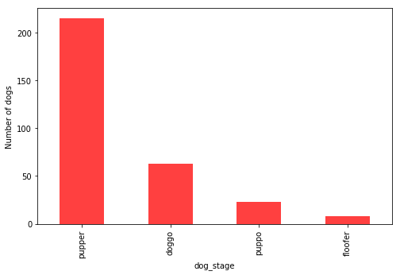

```python
figure_1 = Master_sheet.dog_stage.value_counts()

figure_1.plot(kind='bar', color='red', title= '', alpha =.75, figsize=(8,5))

# graph labels
plt.xlabel('dog_stage')
plt.ylabel('Number of dogs');
```

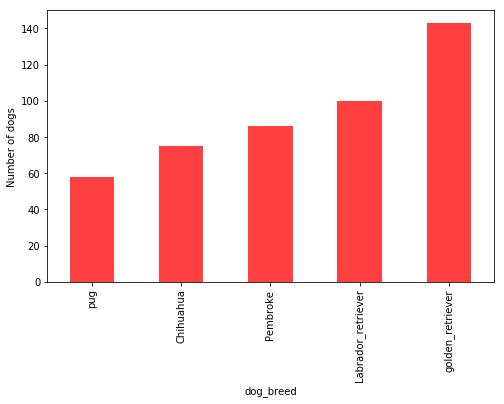

```python
figure_2 = Master_sheet.dog_breed.value_counts()[4::-1]

figure_2.plot(kind='bar', color='red', title= '', alpha =.75, figsize=(8,5))

# graph labels
plt.xlabel('dog_breed')
plt.ylabel('Number of dogs');
```

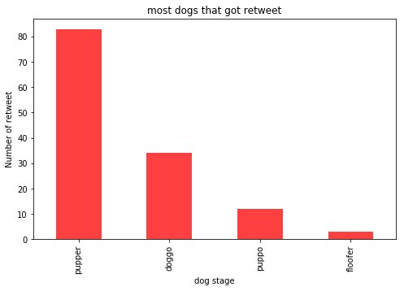

```python
figure_3 = Master_sheet.query('retweet').groupby("dog_stage")["dog_breed"].count().sort_values(ascending=False)

figure_3.plot(kind='bar', color='red', title= 'most dogs that got retweet', alpha =.75, figsize=(8,5))

# graph labels
plt.xlabel('dog stage')
plt.ylabel('Number of retweet');
```

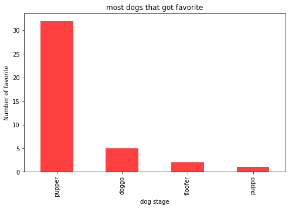

```python
figure_4 = Master_sheet.query('favorite').groupby("dog_stage")["dog_breed"].count().sort_values(ascending=False)

figure_4.plot(kind='bar', color='red', title= 'most dogs that got favorite', alpha =.75, figsize=(8,5))
# graph labels
plt.xlabel('dog stage')
plt.ylabel('Number of favorite');
```